**Idiom + Algorithm Studio** Read-only preview here; open the hosted notebook for Colab execution and editing. Download [Run in Colab ↗](https://huggingface.co/spaces/dku-infosci301-Autumn2026/week2-visualization-gallery-template/blob/main/notebooks/INFOSCI301_Week2_Idiom_Algorithm_Gallery_Python_R.ipynb)

INFOSCI 301 · WEEK 2 · IDIOM + ALGORITHM STUDIO

# Choose the form. Trace the computation.

A second Colab for every leaf in the class decision tree: 38 rendered idioms, paired Python and R recipes, and a 72-package reference atlas.

> **Teaching data only.** Every gallery example below uses deterministic synthetic data to demonstrate visual grammar. Replace it with your project data, re-check the action + target, and do not treat any example value as domain evidence.

## Use this notebook in three decisions

| 1 · Choose | 2 · Run | 3 · Justify |
| --- | --- | --- |
| Start from **Compare**, **Understand Variation**, or **Reveal Structure**; then inspect every leaf and its required data. | Select one idiom. Run the Python figure immediately, copy the paired R recipe, or optionally execute the selected R code. | Choose a package because it supports the transformation, rendering, interaction, scale, accessibility, and reproducibility you need. |

The decision tree selects an **idiom**. A library implements it. The **algorithm** is the reproducible sequence between raw attributes and rendered marks.

```python
# @title 0 · Prepare the gallery
from pathlib import Path
import json, shutil, subprocess, textwrap

import matplotlib.pyplot as plt
import numpy as np
import pandas as pd
from IPython.display import HTML, Markdown, display
from matplotlib.colors import ListedColormap
from matplotlib.patches import FancyArrowPatch, PathPatch, Rectangle, Wedge
from matplotlib.path import Path as MplPath

OUTPUT_DIR = Path("idiom_algorithm_outputs")
OUTPUT_DIR.mkdir(exist_ok=True)

COLORS = {
    "ink":"#18324A", "muted":"#657488", "blue":"#315EFB",
    "teal":"#14877D", "amber":"#D97706", "red":"#C2413A",
    "line":"#CBD5E1", "paper":"#F5F7FB",
}
PALETTE = [COLORS["blue"], COLORS["teal"], COLORS["amber"], COLORS["red"]]
ROOT_COLORS = {"Compare":COLORS["blue"], "Understand variation":COLORS["teal"], "Reveal structure":COLORS["amber"]}
plt.rcParams.update({
    "font.family":"DejaVu Sans", "figure.facecolor":"white", "axes.facecolor":"white",
    "axes.titleweight":"bold", "axes.labelcolor":COLORS["muted"],
    "xtick.color":COLORS["muted"], "ytick.color":COLORS["muted"],
})
print("Ready · outputs:", OUTPUT_DIR.resolve())
```

```
Ready · outputs: /workspace/scratch/81e4611d448d/idiom_algorithm_outputs
```

# 1 · Choose through the class decision tree

### Three roots

- **Compare:** values/ranks; change/groups; composition/profiles.
- **Understand Variation:** one variable; relationships/density; uncertainty/models.
- **Reveal Structure:** hierarchy/flow; cycles/opposition; arranged tables.

The 38 leaves below match the tutorial exactly. The table also states the required data/attribute structure and the action + target so students can reject a visually attractive but invalid choice.

```python
# @title 1.1 · Load the exact 38-leaf decision matrix
idiom_catalog = pd.DataFrame([{'root': 'Compare', 'family': 'Values and ranks', 'idiom': 'Sorted bar', 'selection_cue': 'Compare magnitudes on a shared zero baseline.', 'caution': '', 'leaf': 1, 'data_requirement': 'Table · categorical key + quantitative value', 'action_target': 'Compare → values / ranks', 'marks_channels': 'bars · aligned length + ordered position', 'algorithm': 'aggregate by category → sort descending → draw from zero → label values', 'python_tool': 'Matplotlib', 'python_url': 'https://matplotlib.org/stable/gallery/index.html', 'r_tool': 'ggplot2', 'r_url': 'https://ggplot2.tidyverse.org/', 'python_recipe': "s = df.groupby('group')['value'].sum().sort_values()\ns.plot.barh(color='#315EFB')", 'r_recipe': "library(ggplot2)\nggplot(df, aes(reorder(group, value), value)) + geom_col(fill='#315EFB') + coord_flip()"}, {'root': 'Compare', 'family': 'Values and ranks', 'idiom': 'Dot plot', 'selection_cue': 'Compare positions with less ink than bars.', 'caution': '', 'leaf': 2, 'data_requirement': 'Table · categorical key + quantitative value', 'action_target': 'Compare → values / ranks', 'marks_channels': 'points · aligned position', 'algorithm': 'aggregate by category → sort → encode value as aligned position → label', 'python_tool': 'Matplotlib', 'python_url': 'https://matplotlib.org/stable/gallery/index.html', 'r_tool': 'ggplot2', 'r_url': 'https://ggplot2.tidyverse.org/', 'python_recipe': "s = df.groupby('group')['value'].sum().sort_values()\nplt.hlines(s.index, 0, s); plt.scatter(s, s.index)", 'r_recipe': "library(ggplot2)\nggplot(df, aes(value, reorder(group, value))) + geom_point(size=3, colour='#315EFB')"}, {'root': 'Compare', 'family': 'Values and ranks', 'idiom': 'Lollipop', 'selection_cue': 'Emphasize endpoints while retaining a baseline.', 'caution': '', 'leaf': 3, 'data_requirement': 'Table · categorical key + quantitative value', 'action_target': 'Compare → values / ranks', 'marks_channels': 'rules + points · endpoint position', 'algorithm': 'aggregate → sort → draw baseline-to-value rules → emphasize endpoints', 'python_tool': 'Matplotlib', 'python_url': 'https://matplotlib.org/stable/gallery/index.html', 'r_tool': 'ggplot2', 'r_url': 'https://ggplot2.tidyverse.org/', 'python_recipe': "s = df.groupby('group')['value'].sum().sort_values()\nplt.vlines(s.index, 0, s); plt.scatter(s.index, s)", 'r_recipe': 'library(ggplot2)\nggplot(df, aes(group, value)) + geom_segment(aes(xend=group, y=0, yend=value)) + geom_point(size=3)'}, {'root': 'Compare', 'family': 'Change and groups', 'idiom': 'Slope graph', 'selection_cue': 'Compare two time points across groups.', 'caution': '', 'leaf': 4, 'data_requirement': 'Table · group + two ordered states + quantitative value', 'action_target': 'Compare → change between two states', 'marks_channels': 'lines + points · slope and endpoint position', 'algorithm': 'pivot two states → keep identical scale → connect each group → label endpoints', 'python_tool': 'plotnine', 'python_url': 'https://plotnine.org/gallery.html', 'r_tool': 'ggplot2', 'r_url': 'https://ggplot2.tidyverse.org/', 'python_recipe': "wide = df.pivot(index='group', columns='period', values='value')\nfor _, row in wide.iterrows(): plt.plot(wide.columns, row, marker='o')", 'r_recipe': 'library(ggplot2)\nggplot(df, aes(period, value, group=group, colour=group)) + geom_line() + geom_point()'}, {'root': 'Compare', 'family': 'Change and groups', 'idiom': 'Dumbbell', 'selection_cue': 'Compare paired values and the gap between them.', 'caution': '', 'leaf': 5, 'data_requirement': 'Table · group + paired condition + quantitative value', 'action_target': 'Compare → paired values and gaps', 'marks_channels': 'rules + paired points · distance and position', 'algorithm': 'pivot paired conditions → compute/display gap → draw shared interval + endpoints', 'python_tool': 'Matplotlib', 'python_url': 'https://matplotlib.org/stable/gallery/index.html', 'r_tool': 'ggplot2', 'r_url': 'https://ggplot2.tidyverse.org/', 'python_recipe': "wide = df.pivot(index='group', columns='condition', values='value')\nplt.hlines(wide.index, wide.iloc[:,0], wide.iloc[:,1]); plt.scatter(wide.iloc[:,0], wide.index); plt.scatter(wide.iloc[:,1], wide.index)", 'r_recipe': 'library(ggplot2)\nggplot(wide, aes(x=before, xend=after, y=group, yend=group)) + geom_segment() + geom_point(aes(x=before)) + geom_point(aes(x=after))'}, {'root': 'Compare', 'family': 'Change and groups', 'idiom': 'Line chart', 'selection_cue': 'Follow ordered change; do not connect unordered categories.', 'caution': '', 'leaf': 6, 'data_requirement': 'Table · ordered time + quantitative value + optional group', 'action_target': 'Compare → ordered change', 'marks_channels': 'lines · ordered x position + y position', 'algorithm': 'sort ordered x → group series → connect only adjacent ordered observations → check gaps', 'python_tool': 'pandas plotting', 'python_url': 'https://pandas.pydata.org/docs/user_guide/visualization.html', 'r_tool': 'ggplot2', 'r_url': 'https://ggplot2.tidyverse.org/', 'python_recipe': "for key, g in df.sort_values('time').groupby('group'):\n    plt.plot(g.time, g.value, marker='o', label=key)", 'r_recipe': 'library(ggplot2)\nggplot(df, aes(time, value, colour=group)) + geom_line() + geom_point()'}, {'root': 'Compare', 'family': 'Change and groups', 'idiom': 'Small multiples', 'selection_cue': 'Compare repeated panels with aligned scales.', 'caution': '', 'leaf': 7, 'data_requirement': 'Table · facet category + shared x/y attributes', 'action_target': 'Compare → repeated groups on aligned scales', 'marks_channels': 'repeated panels · shared position scales', 'algorithm': 'split by facet → apply identical scales → render repeated panels → compare', 'python_tool': 'Seaborn', 'python_url': 'https://seaborn.pydata.org/examples/index.html', 'r_tool': 'ggplot2', 'r_url': 'https://ggplot2.tidyverse.org/', 'python_recipe': "import seaborn as sns\nsns.relplot(data=df, x='time', y='value', col='group', col_wrap=3, kind='line', facet_kws={'sharey':True})", 'r_recipe': 'library(ggplot2)\nggplot(df, aes(time, value)) + geom_line() + facet_wrap(~group) + coord_cartesian(ylim=range(df$value))'}, {'root': 'Compare', 'family': 'Composition and profiles', 'idiom': 'Stacked bar', 'selection_cue': 'Compare totals and a limited number of parts.', 'caution': '', 'leaf': 8, 'data_requirement': 'Table · whole + part categories + quantitative value', 'action_target': 'Compare → totals and composition', 'marks_channels': 'stacked bars · length + color', 'algorithm': 'aggregate parts within wholes → choose stable order → cumulative stack → label totals', 'python_tool': 'pandas plotting', 'python_url': 'https://pandas.pydata.org/docs/user_guide/visualization.html', 'r_tool': 'ggplot2', 'r_url': 'https://ggplot2.tidyverse.org/', 'python_recipe': "wide = df.pivot_table(index='whole', columns='part', values='value', aggfunc='sum')\nwide.plot.bar(stacked=True)", 'r_recipe': 'library(ggplot2)\nggplot(df, aes(whole, value, fill=part)) + geom_col()'}, {'root': 'Compare', 'family': 'Composition and profiles', 'idiom': '100% stacked', 'selection_cue': 'Compare proportions when totals are secondary.', 'caution': '', 'leaf': 9, 'data_requirement': 'Table · whole + part categories + quantitative value', 'action_target': 'Compare → normalized composition', 'marks_channels': 'normalized bars · proportion length + color', 'algorithm': 'aggregate → divide each part by its whole → cumulative stack → show denominator', 'python_tool': 'pandas plotting', 'python_url': 'https://pandas.pydata.org/docs/user_guide/visualization.html', 'r_tool': 'ggplot2', 'r_url': 'https://ggplot2.tidyverse.org/', 'python_recipe': "wide = df.pivot_table(index='whole', columns='part', values='value', aggfunc='sum')\n(wide.div(wide.sum(axis=1), axis=0)).plot.bar(stacked=True)", 'r_recipe': "library(ggplot2)\nggplot(df, aes(whole, value, fill=part)) + geom_col(position='fill') + scale_y_continuous(labels=scales::percent)"}, {'root': 'Compare', 'family': 'Composition and profiles', 'idiom': 'Donut', 'selection_cue': 'Use only for a few parts; angles are imprecise.', 'caution': 'Use sparingly', 'leaf': 10, 'data_requirement': 'Table · few part categories + quantitative value', 'action_target': 'Compare → coarse part-to-whole', 'marks_channels': 'arc sectors · angle/area + color', 'algorithm': 'aggregate few parts → compute proportions/angles → render arcs → print values', 'python_tool': 'Matplotlib', 'python_url': 'https://matplotlib.org/stable/gallery/index.html', 'r_tool': 'ggplot2', 'r_url': 'https://ggplot2.tidyverse.org/', 'python_recipe': "s = df.groupby('part')['value'].sum()\nplt.pie(s, labels=s.index, wedgeprops={'width':.38}, autopct='%1.0f%%')", 'r_recipe': "library(ggplot2)\nggplot(df, aes(x=2, y=value, fill=part)) + geom_col() + coord_polar(theta='y') + xlim(.5, 2.5)"}, {'root': 'Compare', 'family': 'Composition and profiles', 'idiom': 'Aligned profile', 'selection_cue': 'Compare many measures on shared aligned axes.', 'caution': '', 'leaf': 11, 'data_requirement': 'Table · entity + measure + quantitative value', 'action_target': 'Compare → multivariate profiles', 'marks_channels': 'points/lines · aligned measure axes', 'algorithm': 'reshape measures long → normalize only if justified → align axes → connect profiles', 'python_tool': 'Matplotlib', 'python_url': 'https://matplotlib.org/stable/gallery/index.html', 'r_tool': 'ggplot2', 'r_url': 'https://ggplot2.tidyverse.org/', 'python_recipe': "for key, g in df.groupby('entity'):\n    plt.plot(g.metric, g.value, marker='o', label=key)", 'r_recipe': 'library(ggplot2)\nggplot(df, aes(metric, value, group=entity, colour=entity)) + geom_line() + geom_point()'}, {'root': 'Compare', 'family': 'Composition and profiles', 'idiom': 'Radar', 'selection_cue': 'Only for a small, common scale; aligned profiles are often clearer.', 'caution': 'Requires justification', 'leaf': 12, 'data_requirement': 'Table · entity + cyclic metric positions + common-scale values', 'action_target': 'Compare → compact profile shape', 'marks_channels': 'radial polygon · angle + radius', 'algorithm': 'verify common scale → order axes deliberately → close polygon → retain numeric context', 'python_tool': 'Matplotlib', 'python_url': 'https://matplotlib.org/stable/gallery/index.html', 'r_tool': 'ggplot2', 'r_url': 'https://ggplot2.tidyverse.org/', 'python_recipe': "theta = np.linspace(0, 2*np.pi, len(values), endpoint=False)\nax = plt.subplot(projection='polar'); ax.plot(np.r_[theta,theta[0]], np.r_[values,values[0]])", 'r_recipe': 'library(ggplot2)\nggplot(df, aes(metric, value, group=entity, colour=entity)) + geom_polygon(fill=NA) + coord_polar()'}, {'root': 'Understand variation', 'family': 'One variable', 'idiom': 'Histogram', 'selection_cue': 'Show binned distribution shape; test bin sensitivity.', 'caution': '', 'leaf': 13, 'data_requirement': 'Table · one quantitative attribute', 'action_target': 'Summarize → binned distribution', 'marks_channels': 'bins/bars · position + count length', 'algorithm': 'choose/test bin edges → count observations → draw aligned bars → disclose bins', 'python_tool': 'Seaborn', 'python_url': 'https://seaborn.pydata.org/examples/index.html', 'r_tool': 'ggplot2', 'r_url': 'https://ggplot2.tidyverse.org/', 'python_recipe': "import seaborn as sns\nsns.histplot(data=df, x='value', bins=20)", 'r_recipe': "library(ggplot2)\nggplot(df, aes(value)) + geom_histogram(bins=20, fill='#315EFB', colour='white')"}, {'root': 'Understand variation', 'family': 'One variable', 'idiom': 'KDE', 'selection_cue': 'Show smoothed density; disclose bandwidth.', 'caution': '', 'leaf': 14, 'data_requirement': 'Table · one quantitative attribute', 'action_target': 'Summarize → smoothed density', 'marks_channels': 'density line/area · position + height', 'algorithm': 'choose kernel/bandwidth → estimate density → normalize area → disclose bandwidth', 'python_tool': 'Seaborn', 'python_url': 'https://seaborn.pydata.org/examples/index.html', 'r_tool': 'ggplot2', 'r_url': 'https://ggplot2.tidyverse.org/', 'python_recipe': "import seaborn as sns\nsns.kdeplot(data=df, x='value', bw_adjust=1, fill=True)", 'r_recipe': "library(ggplot2)\nggplot(df, aes(value)) + geom_density(fill='#315EFB', alpha=.3, adjust=1)"}, {'root': 'Understand variation', 'family': 'One variable', 'idiom': 'ECDF', 'selection_cue': 'Show every observation without bin or bandwidth choice.', 'caution': '', 'leaf': 15, 'data_requirement': 'Table · one quantitative attribute', 'action_target': 'Summarize → cumulative distribution', 'marks_channels': 'step line · value position + cumulative proportion', 'algorithm': 'sort values → assign cumulative ranks n/N → draw steps → retain every observation', 'python_tool': 'Seaborn', 'python_url': 'https://seaborn.pydata.org/examples/index.html', 'r_tool': 'ggplot2', 'r_url': 'https://ggplot2.tidyverse.org/', 'python_recipe': "import seaborn as sns\nsns.ecdfplot(data=df, x='value')", 'r_recipe': "library(ggplot2)\nggplot(df, aes(value)) + stat_ecdf(geom='step')"}, {'root': 'Understand variation', 'family': 'One variable', 'idiom': 'Box plot', 'selection_cue': 'Compare robust summaries; show raw data when sample size matters.', 'caution': '', 'leaf': 16, 'data_requirement': 'Table · quantitative value + optional category', 'action_target': 'Compare → robust distribution summaries', 'marks_channels': 'box + whiskers · ordered position', 'algorithm': 'compute quartiles/IQR → set whisker rule → mark outliers → disclose n', 'python_tool': 'Seaborn', 'python_url': 'https://seaborn.pydata.org/examples/index.html', 'r_tool': 'ggplot2', 'r_url': 'https://ggplot2.tidyverse.org/', 'python_recipe': "import seaborn as sns\nsns.boxplot(data=df, x='group', y='value'); sns.stripplot(data=df, x='group', y='value', color='black', alpha=.35)", 'r_recipe': 'library(ggplot2)\nggplot(df, aes(group, value)) + geom_boxplot() + geom_jitter(width=.08, alpha=.3)'}, {'root': 'Understand variation', 'family': 'One variable', 'idiom': 'Violin', 'selection_cue': 'Compare distribution shape; include scale and sample context.', 'caution': '', 'leaf': 17, 'data_requirement': 'Table · quantitative value + optional category', 'action_target': 'Compare → distribution shapes', 'marks_channels': 'mirrored density area · width', 'algorithm': 'estimate density per group → mirror width → align groups → disclose bandwidth and n', 'python_tool': 'Seaborn', 'python_url': 'https://seaborn.pydata.org/examples/index.html', 'r_tool': 'ggplot2', 'r_url': 'https://ggplot2.tidyverse.org/', 'python_recipe': "import seaborn as sns\nsns.violinplot(data=df, x='group', y='value', inner='quartile')", 'r_recipe': 'library(ggplot2)\nggplot(df, aes(group, value)) + geom_violin() + geom_boxplot(width=.12)'}, {'root': 'Understand variation', 'family': 'One variable', 'idiom': 'Raincloud', 'selection_cue': 'Combine density, summary, and observations.', 'caution': '', 'leaf': 18, 'data_requirement': 'Table · quantitative value + optional category', 'action_target': 'Compare → density, summary, and observations', 'marks_channels': 'half density + box + points', 'algorithm': 'estimate half-density → compute robust summary → jitter raw points → align layers', 'python_tool': 'PtitPrince', 'python_url': 'https://github.com/pog87/PtitPrince', 'r_tool': 'ggdist', 'r_url': 'https://mjskay.github.io/ggdist/', 'python_recipe': "import PtitPrince as pt\npt.RainCloud(data=df, x='group', y='value', orient='v')", 'r_recipe': 'library(ggplot2); library(ggdist)\nggplot(df, aes(group, value, fill=group)) + stat_halfeye() + geom_jitter(width=.08, alpha=.3)'}, {'root': 'Understand variation', 'family': 'Relationships and density', 'idiom': 'Scatterplot', 'selection_cue': 'Inspect two quantitative attributes.', 'caution': '', 'leaf': 19, 'data_requirement': 'Table · two quantitative attributes', 'action_target': 'Discover → association, clusters, outliers', 'marks_channels': 'points · x/y position', 'algorithm': 'filter valid x/y pairs → map both to position → manage overlap → annotate outliers', 'python_tool': 'Altair', 'python_url': 'https://altair-viz.github.io/gallery/index.html', 'r_tool': 'ggplot2', 'r_url': 'https://ggplot2.tidyverse.org/', 'python_recipe': "import altair as alt\nalt.Chart(df).mark_circle().encode(x='x:Q', y='y:Q', color='group:N', tooltip=list(df.columns))", 'r_recipe': 'library(ggplot2)\nggplot(df, aes(x, y, colour=group)) + geom_point(alpha=.65)'}, {'root': 'Understand variation', 'family': 'Relationships and density', 'idiom': 'Regression view', 'selection_cue': 'Show fitted relationship with uncertainty and assumptions.', 'caution': '', 'leaf': 20, 'data_requirement': 'Table · predictor + outcome quantitative attributes', 'action_target': 'Summarize → fitted relationship and uncertainty', 'marks_channels': 'points + fitted line + interval band', 'algorithm': 'fit stated model → predict on ordered x → compute interval → plot data + fit + uncertainty', 'python_tool': 'statsmodels graphics', 'python_url': 'https://www.statsmodels.org/stable/graphics.html', 'r_tool': 'ggplot2', 'r_url': 'https://ggplot2.tidyverse.org/', 'python_recipe': "import seaborn as sns\nsns.regplot(data=df, x='x', y='y', ci=95)", 'r_recipe': "library(ggplot2)\nggplot(df, aes(x, y)) + geom_point() + geom_smooth(method='lm', se=TRUE)"}, {'root': 'Understand variation', 'family': 'Relationships and density', 'idiom': 'Hexbin', 'selection_cue': 'Aggregate dense points to reveal concentration.', 'caution': '', 'leaf': 21, 'data_requirement': 'Table · many x/y quantitative observations', 'action_target': 'Summarize → two-dimensional density', 'marks_channels': 'hexagonal bins · x/y position + color', 'algorithm': 'choose hex grid/resolution → count points per cell → encode count → show color scale', 'python_tool': 'Matplotlib', 'python_url': 'https://matplotlib.org/stable/gallery/index.html', 'r_tool': 'ggplot2', 'r_url': 'https://ggplot2.tidyverse.org/', 'python_recipe': "plt.hexbin(df.x, df.y, gridsize=24, mincnt=1, cmap='viridis'); plt.colorbar(label='count')", 'r_recipe': 'library(ggplot2); library(hexbin)\nggplot(df, aes(x, y)) + geom_hex(bins=24) + scale_fill_viridis_c()'}, {'root': 'Understand variation', 'family': 'Relationships and density', 'idiom': 'Pair plot', 'selection_cue': 'Scan many pairwise relationships; avoid tiny unreadable panels.', 'caution': '', 'leaf': 22, 'data_requirement': 'Table · three or more quantitative attributes', 'action_target': 'Discover → pairwise relationships', 'marks_channels': 'faceted points/distributions · repeated position', 'algorithm': 'select variables → create pairwise grid → place distributions on diagonal → share scales', 'python_tool': 'Seaborn', 'python_url': 'https://seaborn.pydata.org/examples/index.html', 'r_tool': 'GGally', 'r_url': 'https://ggobi.github.io/ggally/', 'python_recipe': "import seaborn as sns\nsns.pairplot(df, vars=['a','b','c'], hue='group', corner=True)", 'r_recipe': "library(GGally)\nggpairs(df, columns=c('a','b','c'), aes(colour=group, alpha=.5))"}, {'root': 'Understand variation', 'family': 'Relationships and density', 'idiom': 'Correlation heatmap', 'selection_cue': 'Reveal a matrix pattern after justified ordering.', 'caution': '', 'leaf': 23, 'data_requirement': 'Derived symmetric matrix · quantitative association', 'action_target': 'Discover → matrix pattern', 'marks_channels': 'matrix cells · color', 'algorithm': 'handle missingness → compute stated correlation → order variables → encode diverging color', 'python_tool': 'Seaborn', 'python_url': 'https://seaborn.pydata.org/examples/index.html', 'r_tool': 'ComplexHeatmap', 'r_url': 'https://jokergoo.github.io/ComplexHeatmap-reference/book/', 'python_recipe': "import seaborn as sns\ncorr = df.select_dtypes('number').corr()\nsns.heatmap(corr, vmin=-1, vmax=1, cmap='vlag', annot=True)", 'r_recipe': "library(ComplexHeatmap)\nHeatmap(cor(df[c('a','b','c')], use='pairwise.complete.obs'), name='r')"}, {'root': 'Understand variation', 'family': 'Relationships and density', 'idiom': '2D contour', 'selection_cue': 'Show a continuous surface without unnecessary 3D perspective.', 'caution': '', 'leaf': 24, 'data_requirement': 'Field or table · x/y coordinates + quantitative surface', 'action_target': 'Locate → levels and gradients', 'marks_channels': 'isolines/filled bands · x/y position + level', 'algorithm': 'interpolate/model surface → choose levels → trace isolines/fills → verify topology', 'python_tool': 'Matplotlib', 'python_url': 'https://matplotlib.org/stable/gallery/index.html', 'r_tool': 'ggplot2', 'r_url': 'https://ggplot2.tidyverse.org/', 'python_recipe': "grid = df.pivot(index='y', columns='x', values='z')\nplt.contourf(grid.columns, grid.index, grid.values, levels=10, cmap='viridis'); plt.colorbar()", 'r_recipe': 'library(ggplot2)\nggplot(df, aes(x, y, z=z)) + geom_contour_filled() + coord_equal()'}, {'root': 'Understand variation', 'family': 'Uncertainty and models', 'idiom': 'Interval / forest', 'selection_cue': 'Compare estimates and uncertainty on aligned axes.', 'caution': '', 'leaf': 25, 'data_requirement': 'Table · estimate + lower/upper bounds + category', 'action_target': 'Compare → estimates and uncertainty', 'marks_channels': 'points + intervals · aligned position', 'algorithm': 'collect estimates/bounds → sort categories → draw intervals + point estimates → mark reference', 'python_tool': 'statsmodels graphics', 'python_url': 'https://www.statsmodels.org/stable/graphics.html', 'r_tool': 'forestplot', 'r_url': 'https://cran.r-project.org/package=forestplot', 'python_recipe': "plt.errorbar(df.estimate, df.label, xerr=[df.estimate-df.lower, df.upper-df.estimate], fmt='o')\nplt.axvline(0, color='0.5', lw=1)", 'r_recipe': 'library(forestplot)\nforestplot(labeltext=df$label, mean=df$estimate, lower=df$lower, upper=df$upper, zero=0)'}, {'root': 'Understand variation', 'family': 'Uncertainty and models', 'idiom': 'Fan chart', 'selection_cue': 'Show forecast uncertainty expanding through time.', 'caution': '', 'leaf': 26, 'data_requirement': 'Table · ordered time + central estimate + nested intervals', 'action_target': 'Explore → forecast uncertainty', 'marks_channels': 'nested interval bands · ordered position + opacity', 'algorithm': 'compute quantiles by time → nest bands widest-to-narrowest → draw center → label coverage', 'python_tool': 'Matplotlib', 'python_url': 'https://matplotlib.org/stable/gallery/index.html', 'r_tool': 'ggplot2', 'r_url': 'https://ggplot2.tidyverse.org/', 'python_recipe': 'plt.fill_between(df.time, df.q10, df.q90, alpha=.18)\nplt.fill_between(df.time, df.q25, df.q75, alpha=.32); plt.plot(df.time, df.median)', 'r_recipe': 'library(ggplot2)\nggplot(df, aes(time, median)) + geom_ribbon(aes(ymin=q10,ymax=q90), alpha=.18) + geom_ribbon(aes(ymin=q25,ymax=q75), alpha=.32) + geom_line()'}, {'root': 'Understand variation', 'family': 'Uncertainty and models', 'idiom': 'Calibration', 'selection_cue': 'Compare predicted probability with observed frequency.', 'caution': '', 'leaf': 27, 'data_requirement': 'Table · predicted probability + observed outcome', 'action_target': 'Evaluate → agreement with reference', 'marks_channels': 'points/line + diagonal reference', 'algorithm': 'bin/estimate predicted probabilities → compute observed frequency → plot against identity → report n', 'python_tool': 'scikit-learn Displays', 'python_url': 'https://scikit-learn.org/stable/visualizations.html', 'r_tool': 'ggplot2', 'r_url': 'https://ggplot2.tidyverse.org/', 'python_recipe': 'from sklearn.calibration import CalibrationDisplay\nCalibrationDisplay.from_predictions(df.outcome, df.probability, n_bins=10)', 'r_recipe': 'library(ggplot2)\nggplot(calibration, aes(predicted, observed)) + geom_abline(slope=1, intercept=0, linetype=2) + geom_line() + geom_point()'}, {'root': 'Understand variation', 'family': 'Uncertainty and models', 'idiom': 'Residual view', 'selection_cue': 'Diagnose model error, structure, and outliers.', 'caution': '', 'leaf': 28, 'data_requirement': 'Table · fitted value + residual', 'action_target': 'Diagnose → model error and structure', 'marks_channels': 'points + zero reference line', 'algorithm': 'fit model → calculate fitted values/residuals → plot against reference zero → inspect pattern', 'python_tool': 'Yellowbrick', 'python_url': 'https://www.scikit-yb.org/en/latest/gallery.html', 'r_tool': 'ggplot2', 'r_url': 'https://ggplot2.tidyverse.org/', 'python_recipe': "import seaborn as sns\nsns.residplot(data=df, x='fitted', y='observed', lowess=True); plt.axhline(0, color='0.5')", 'r_recipe': "library(ggplot2)\nggplot(df, aes(fitted, residual)) + geom_hline(yintercept=0, colour='grey60') + geom_point() + geom_smooth(se=FALSE)"}, {'root': 'Reveal structure', 'family': 'Hierarchy and flow', 'idiom': 'Treemap', 'selection_cue': 'Encode a genuine part-to-whole hierarchy through nested area.', 'caution': '', 'leaf': 29, 'data_requirement': 'Tree · parent/child hierarchy + quantitative weight', 'action_target': 'Summarize → hierarchical part-to-whole', 'marks_channels': 'nested rectangles · area + containment', 'algorithm': 'validate hierarchy → sum child weights → recursively partition area → preserve containment', 'python_tool': 'Plotly', 'python_url': 'https://plotly.com/python/', 'r_tool': 'treemapify', 'r_url': 'https://wilkox.org/treemapify/', 'python_recipe': "import plotly.express as px\npx.treemap(df, path=['parent','child'], values='value', color='value')", 'r_recipe': 'library(ggplot2); library(treemapify)\nggplot(df, aes(area=value, fill=parent, label=child)) + geom_treemap() + geom_treemap_text()'}, {'root': 'Reveal structure', 'family': 'Hierarchy and flow', 'idiom': 'Sunburst', 'selection_cue': 'Show hierarchical depth radially; labels can become difficult.', 'caution': '', 'leaf': 30, 'data_requirement': 'Tree · parent/child hierarchy + quantitative weight', 'action_target': 'Explore → hierarchy and depth', 'marks_channels': 'nested arcs · angle + radial depth', 'algorithm': 'validate hierarchy → aggregate weights → allocate angles → map depth to radius', 'python_tool': 'Plotly', 'python_url': 'https://plotly.com/python/', 'r_tool': 'plotly for R', 'r_url': 'https://plotly.com/r/', 'python_recipe': "import plotly.express as px\npx.sunburst(df, path=['level1','level2'], values='value', color='level1')", 'r_recipe': "library(plotly)\nplot_ly(df, labels=~label, parents=~parent, values=~value, type='sunburst', branchvalues='total')"}, {'root': 'Reveal structure', 'family': 'Hierarchy and flow', 'idiom': 'Sankey', 'selection_cue': 'Show aggregated flows with conserved quantities.', 'caution': '', 'leaf': 31, 'data_requirement': 'Network · source/target + conserved quantitative flow', 'action_target': 'Trace → aggregated flow', 'marks_channels': 'nodes + weighted links · width + connection', 'algorithm': 'aggregate source-target flows → verify conservation → compute node/link layout → encode width', 'python_tool': 'Plotly', 'python_url': 'https://plotly.com/python/', 'r_tool': 'networkD3', 'r_url': 'https://christophergandrud.github.io/networkD3/', 'python_recipe': "import plotly.graph_objects as go\ngo.Figure(go.Sankey(node={'label':labels}, link={'source':source,'target':target,'value':value}))", 'r_recipe': "library(networkD3)\nsankeyNetwork(Links=links, Nodes=nodes, Source='source', Target='target', Value='value', NodeID='name')"}, {'root': 'Reveal structure', 'family': 'Hierarchy and flow', 'idiom': 'Alluvial', 'selection_cue': 'Compare category flows across ordered stages.', 'caution': '', 'leaf': 32, 'data_requirement': 'Table · entity/category at ordered stages + weight', 'action_target': 'Compare → categorical transitions', 'marks_channels': 'stage axes + ribbons · width + path', 'algorithm': 'aggregate category sequences → order stages/categories → compute strata → route weighted ribbons', 'python_tool': 'Plotly', 'python_url': 'https://plotly.com/python/', 'r_tool': 'ggalluvial', 'r_url': 'https://corybrunson.github.io/ggalluvial/', 'python_recipe': "import plotly.express as px\npx.parallel_categories(df, dimensions=['stage1','stage2','stage3'], color='weight')", 'r_recipe': 'library(ggplot2); library(ggalluvial)\nggplot(df, aes(axis1=stage1, axis2=stage2, axis3=stage3, y=weight)) + geom_alluvium(aes(fill=stage1)) + geom_stratum()'}, {'root': 'Reveal structure', 'family': 'Cycles and opposition', 'idiom': 'Polar / Burtin', 'selection_cue': 'Use only for genuinely cyclic variables.', 'caution': '', 'leaf': 33, 'data_requirement': 'Table · genuinely cyclic ordered attribute + value', 'action_target': 'Compare → seasonal or angular pattern', 'marks_channels': 'radial bars · cyclic angle + radius', 'algorithm': 'validate cyclic order → map cycle to angle → map value to radius → retain radial reference', 'python_tool': 'pyCirclize', 'python_url': 'https://moshi4.github.io/pyCirclize/', 'r_tool': 'circlize', 'r_url': 'https://jokergoo.github.io/circlize_book/book/', 'python_recipe': 'from pycirclize import Circos\n# Map genuinely cyclic sectors and values; see the official pyCirclize examples.', 'r_recipe': 'library(circlize)\n# Map genuinely cyclic sectors and quantitative values; see the official circlize book.'}, {'root': 'Reveal structure', 'family': 'Cycles and opposition', 'idiom': 'Population pyramid', 'selection_cue': 'Compare two opposing populations across the same ordered categories.', 'caution': '', 'leaf': 34, 'data_requirement': 'Table · ordered groups + two opposing categories + values', 'action_target': 'Compare → opposition across shared groups', 'marks_channels': 'opposing bars · signed length + shared order', 'algorithm': 'align ordered groups → sign one category negative → mirror shared zero → label absolute values', 'python_tool': 'Matplotlib', 'python_url': 'https://matplotlib.org/stable/gallery/index.html', 'r_tool': 'ggplot2', 'r_url': 'https://ggplot2.tidyverse.org/', 'python_recipe': "y = np.arange(len(df))\nplt.barh(y, -df.left, label='Left'); plt.barh(y, df.right, label='Right'); plt.axvline(0, color='0.3')", 'r_recipe': "library(ggplot2)\nlong$plot_value <- ifelse(long$side=='Left', -long$value, long$value)\nggplot(long, aes(plot_value, ordered_group, fill=side)) + geom_col() + geom_vline(xintercept=0)"}, {'root': 'Reveal structure', 'family': 'Arranged tables', 'idiom': 'Ordered heatmap', 'selection_cue': 'Reveal table structure through meaningful row and column order.', 'caution': '', 'leaf': 35, 'data_requirement': 'Matrix · ordered rows/columns + quantitative cells', 'action_target': 'Discover → clusters, bands, and blocks', 'marks_channels': 'ordered matrix cells · color', 'algorithm': 'construct matrix → choose/reproduce ordering → normalize only if justified → encode color', 'python_tool': 'Seaborn', 'python_url': 'https://seaborn.pydata.org/examples/index.html', 'r_tool': 'ComplexHeatmap', 'r_url': 'https://jokergoo.github.io/ComplexHeatmap-reference/book/', 'python_recipe': "import seaborn as sns\nordered = matrix.loc[row_order, col_order]\nsns.heatmap(ordered, cmap='viridis')", 'r_recipe': "library(ComplexHeatmap)\nHeatmap(matrix[row_order, col_order], name='value', cluster_rows=FALSE, cluster_columns=FALSE)"}, {'root': 'Reveal structure', 'family': 'Arranged tables', 'idiom': 'Faceted table', 'selection_cue': 'Keep exact values while arranging meaningful groups.', 'caution': '', 'leaf': 36, 'data_requirement': 'Table · exact values + grouping attributes', 'action_target': 'Lookup → values within meaningful groups', 'marks_channels': 'text cells + grouping bands', 'algorithm': 'group/sort rows → format exact values → add restrained grouping cues → preserve lookup', 'python_tool': 'pandas plotting', 'python_url': 'https://pandas.pydata.org/docs/user_guide/visualization.html', 'r_tool': 'reactable', 'r_url': 'https://glin.github.io/reactable/articles/examples.html', 'python_recipe': "styled = df.sort_values(['group','item']).style.format(precision=2).background_gradient(subset=['value'])\ndisplay(styled)", 'r_recipe': "library(reactable)\nreactable(df, groupBy='group', searchable=TRUE, defaultSorted='item')"}, {'root': 'Reveal structure', 'family': 'Arranged tables', 'idiom': 'Missingness matrix', 'selection_cue': 'Expose which variables or groups lack evidence.', 'caution': '', 'leaf': 37, 'data_requirement': 'Table · present/absent state for each cell', 'action_target': 'Locate → missing-data structure', 'marks_channels': 'binary cells · color', 'algorithm': 'convert cells to present/absent → order rows/columns → encode binary state → summarize rates', 'python_tool': 'missingno', 'python_url': 'https://github.com/ResidentMario/missingno', 'r_tool': 'ComplexHeatmap', 'r_url': 'https://jokergoo.github.io/ComplexHeatmap-reference/book/', 'python_recipe': "import missingno as msno\nmsno.matrix(df.sort_values('group'))", 'r_recipe': "library(ComplexHeatmap)\nHeatmap(is.na(df) * 1, name='missing', col=c('0'='white','1'='#C2413A'))"}, {'root': 'Reveal structure', 'family': 'Arranged tables', 'idiom': 'UpSet matrix', 'selection_cue': 'Compare intersections when a Venn diagram no longer scales.', 'caution': '', 'leaf': 38, 'data_requirement': 'Set-membership table · binary categories + counts', 'action_target': 'Compare → intersections', 'marks_channels': 'intersection bars + connected membership dots', 'algorithm': 'encode set membership → count unique intersections → sort/filter → link membership dots to bars', 'python_tool': 'UpSetPlot', 'python_url': 'https://upsetplot.readthedocs.io/en/stable/auto_examples/index.html', 'r_tool': 'ComplexHeatmap', 'r_url': 'https://jokergoo.github.io/ComplexHeatmap-reference/book/', 'python_recipe': "from upsetplot import UpSet, from_indicators\nUpSet(from_indicators(['A','B','C'], df), show_counts=True).plot()", 'r_recipe': "library(ComplexHeatmap)\nm = make_comb_mat(df[c('A','B','C')]); UpSet(m)"}])
```

```python
tool_catalog = pd.DataFrame([{'name': 'Matplotlib', 'language': 'Python', 'category': 'grammar', 'use': 'Foundational static, animated, and publication figures.', 'tags': 'bar line scatter animation', 'official_url': 'https://matplotlib.org/stable/gallery/index.html'}, {'name': 'Seaborn', 'language': 'Python', 'category': 'grammar', 'use': 'Statistical graphics with concise data-aware defaults.', 'tags': 'distribution relational categorical', 'official_url': 'https://seaborn.pydata.org/examples/index.html'}, {'name': 'Plotly', 'language': 'Python', 'category': 'grammar', 'use': 'Interactive browser charts, maps, 3D, and dashboards.', 'tags': 'interactive hover map', 'official_url': 'https://plotly.com/python/'}, {'name': 'Altair', 'language': 'Python', 'category': 'grammar', 'use': 'Declarative Vega-Lite grammar for composable charts.', 'tags': 'declarative grammar interactive', 'official_url': 'https://altair-viz.github.io/gallery/index.html'}, {'name': 'Bokeh', 'language': 'Python', 'category': 'grammar', 'use': 'Interactive linked plots and browser applications.', 'tags': 'interactive linked brushing server', 'official_url': 'https://docs.bokeh.org/en/latest/docs/gallery.html'}, {'name': 'HoloViews', 'language': 'Python', 'category': 'grammar', 'use': 'High-level declarative views across plotting backends.', 'tags': 'declarative linked data', 'official_url': 'https://holoviews.org/reference/index.html'}, {'name': 'hvPlot', 'language': 'Python', 'category': 'grammar', 'use': 'Interactive plotting API for pandas, xarray, and more.', 'tags': 'pandas xarray interactive', 'official_url': 'https://hvplot.holoviz.org/reference/index.html'}, {'name': 'plotnine', 'language': 'Python', 'category': 'grammar', 'use': 'Grammar-of-graphics implementation inspired by ggplot2.', 'tags': 'grammar layers facets', 'official_url': 'https://plotnine.org/gallery.html'}, {'name': 'Lets-Plot', 'language': 'Python', 'category': 'grammar', 'use': 'Grammar-of-graphics plots for notebooks and web output.', 'tags': 'grammar interactive notebooks', 'official_url': 'https://lets-plot.org/python/pages/gallery.html'}, {'name': 'Pygal', 'language': 'Python', 'category': 'grammar', 'use': 'Lightweight SVG charts with browser-friendly output.', 'tags': 'svg browser simple', 'official_url': 'https://www.pygal.org/en/stable/documentation/types/index.html'}, {'name': 'pyecharts', 'language': 'Python', 'category': 'grammar', 'use': 'Python bindings for the Apache ECharts ecosystem.', 'tags': 'echarts interactive web', 'official_url': 'https://gallery.pyecharts.org/'}, {'name': 'Panel', 'language': 'Python', 'category': 'grammar', 'use': 'Compose plots, widgets, and data apps across libraries.', 'tags': 'dashboard widgets app', 'official_url': 'https://panel.holoviz.org/gallery/index.html'}, {'name': 'pandas plotting', 'language': 'Python', 'category': 'statistics', 'use': 'Quick plots directly from Series and DataFrames.', 'tags': 'dataframe quick exploratory', 'official_url': 'https://pandas.pydata.org/docs/user_guide/visualization.html'}, {'name': 'statsmodels graphics', 'language': 'Python', 'category': 'statistics', 'use': 'Regression, diagnostic, time-series, and model plots.', 'tags': 'regression residual diagnostic', 'official_url': 'https://www.statsmodels.org/stable/graphics.html'}, {'name': 'scikit-learn Displays', 'language': 'Python', 'category': 'statistics', 'use': 'Model evaluation displays with estimator integration.', 'tags': 'machine learning calibration roc confusion', 'official_url': 'https://scikit-learn.org/stable/visualizations.html'}, {'name': 'Yellowbrick', 'language': 'Python', 'category': 'statistics', 'use': 'Visual diagnostics for machine-learning workflows.', 'tags': 'machine learning diagnostic residual', 'official_url': 'https://www.scikit-yb.org/en/latest/gallery.html'}, {'name': 'ArviZ', 'language': 'Python', 'category': 'statistics', 'use': 'Exploratory analysis and diagnostics for Bayesian models.', 'tags': 'bayesian posterior interval', 'official_url': 'https://python.arviz.org/en/stable/examples/index.html'}, {'name': 'corner.py', 'language': 'Python', 'category': 'statistics', 'use': 'Multidimensional posterior and parameter distributions.', 'tags': 'bayesian pairplot distribution', 'official_url': 'https://corner.readthedocs.io/en/latest/pages/quickstart/'}, {'name': 'missingno', 'language': 'Python', 'category': 'statistics', 'use': 'Missing-data matrices, bars, heatmaps, and dendrograms.', 'tags': 'missingness data quality', 'official_url': 'https://github.com/ResidentMario/missingno'}, {'name': 'UpSetPlot', 'language': 'Python', 'category': 'statistics', 'use': 'Scalable set-intersection visualization.', 'tags': 'sets intersections upset', 'official_url': 'https://upsetplot.readthedocs.io/en/stable/auto_examples/index.html'}, {'name': 'JoyPy', 'language': 'Python', 'category': 'statistics', 'use': 'Ridgeline distribution plots built on Matplotlib.', 'tags': 'ridgeline density distribution', 'official_url': 'https://github.com/leotac/joypy'}, {'name': 'PtitPrince', 'language': 'Python', 'category': 'statistics', 'use': 'Raincloud plots combining density, box, and points.', 'tags': 'raincloud distribution', 'official_url': 'https://github.com/pog87/PtitPrince'}, {'name': 'SciencePlots', 'language': 'Python', 'category': 'statistics', 'use': 'Matplotlib styles for scientific publication contexts.', 'tags': 'publication style journal', 'official_url': 'https://github.com/garrettj403/SciencePlots'}, {'name': 'statannotations', 'language': 'Python', 'category': 'statistics', 'use': 'Statistical annotations for seaborn and Matplotlib plots.', 'tags': 'significance annotation box', 'official_url': 'https://github.com/trevismd/statannotations'}, {'name': 'GeoPandas', 'language': 'Python', 'category': 'specialized', 'use': 'Geospatial vector data analysis and mapping.', 'tags': 'map geometry spatial', 'official_url': 'https://geopandas.org/en/stable/docs/user_guide/mapping.html'}, {'name': 'Cartopy', 'language': 'Python', 'category': 'specialized', 'use': 'Projected maps and geospatial data transformations.', 'tags': 'map projection geospatial', 'official_url': 'https://cartopy.readthedocs.io/stable/gallery/index.html'}, {'name': 'Folium', 'language': 'Python', 'category': 'specialized', 'use': 'Interactive Leaflet maps from Python.', 'tags': 'interactive map leaflet', 'official_url': 'https://python-visualization.github.io/folium/latest/getting_started.html'}, {'name': 'pydeck', 'language': 'Python', 'category': 'specialized', 'use': 'Large-scale layered geospatial visualizations with deck.gl.', 'tags': 'map layers gpu spatial', 'official_url': 'https://deckgl.readthedocs.io/en/latest/gallery/index.html'}, {'name': 'Datashader', 'language': 'Python', 'category': 'specialized', 'use': 'Rasterize and aggregate massive point or line datasets.', 'tags': 'large data density raster', 'official_url': 'https://datashader.org/user_guide/index.html'}, {'name': 'NetworkX', 'language': 'Python', 'category': 'specialized', 'use': 'Network analysis, layouts, and graph drawing.', 'tags': 'network graph topology', 'official_url': 'https://networkx.org/documentation/stable/auto_examples/index.html'}, {'name': 'PyVis', 'language': 'Python', 'category': 'specialized', 'use': 'Interactive browser-based network visualization.', 'tags': 'network interactive browser', 'official_url': 'https://pyvis.readthedocs.io/en/latest/'}, {'name': 'OSMnx', 'language': 'Python', 'category': 'specialized', 'use': 'Download, analyze, and visualize street networks.', 'tags': 'network street map osm', 'official_url': 'https://osmnx.readthedocs.io/en/stable/'}, {'name': 'contextily', 'language': 'Python', 'category': 'specialized', 'use': 'Add web basemaps to geospatial plots.', 'tags': 'basemap tiles spatial', 'official_url': 'https://contextily.readthedocs.io/en/latest/intro_guide.html'}, {'name': 'GeoViews', 'language': 'Python', 'category': 'specialized', 'use': 'Geographic visualization built on HoloViews.', 'tags': 'map geographic interactive', 'official_url': 'https://geoviews.org/gallery/index.html'}, {'name': 'Graphviz', 'language': 'Python', 'category': 'specialized', 'use': 'Graph and hierarchy layout through the Graphviz engine.', 'tags': 'network tree layout', 'official_url': 'https://graphviz.readthedocs.io/en/stable/examples.html'}, {'name': 'pyCirclize', 'language': 'Python', 'category': 'specialized', 'use': 'Circular genome, chord, and sector visualizations.', 'tags': 'circular chord polar', 'official_url': 'https://moshi4.github.io/pyCirclize/'}, {'name': 'ggplot2', 'language': 'R', 'category': 'grammar', 'use': 'Layered grammar of graphics for analytical and publication figures.', 'tags': 'grammar layers facets', 'official_url': 'https://ggplot2.tidyverse.org/'}, {'name': 'plotly for R', 'language': 'R', 'category': 'grammar', 'use': 'Interactive Plotly figures and ggplotly conversion.', 'tags': 'interactive hover web', 'official_url': 'https://plotly.com/r/'}, {'name': 'Shiny', 'language': 'R', 'category': 'grammar', 'use': 'Reactive interactive applications and dashboards.', 'tags': 'app reactive dashboard', 'official_url': 'https://shiny.posit.co/r/gallery/'}, {'name': 'highcharter', 'language': 'R', 'category': 'grammar', 'use': 'Interactive Highcharts visualizations from R.', 'tags': 'interactive web time series', 'official_url': 'https://jkunst.com/highcharter/'}, {'name': 'echarts4r', 'language': 'R', 'category': 'grammar', 'use': 'R interface to Apache ECharts with rich interaction.', 'tags': 'interactive echarts web', 'official_url': 'https://echarts4r.john-coene.com/'}, {'name': 'ggiraph', 'language': 'R', 'category': 'grammar', 'use': 'Interactive SVG output for ggplot2 graphics.', 'tags': 'ggplot interactive svg', 'official_url': 'https://davidgohel.github.io/ggiraph/'}, {'name': 'lattice', 'language': 'R', 'category': 'grammar', 'use': 'Trellis graphics for multivariable conditioning.', 'tags': 'facets conditioning multivariate', 'official_url': 'https://lattice.r-forge.r-project.org/'}, {'name': 'r2d3', 'language': 'R', 'category': 'grammar', 'use': 'Build custom D3 visualizations from R.', 'tags': 'd3 custom interactive', 'official_url': 'https://rstudio.github.io/r2d3/'}, {'name': 'htmlwidgets', 'language': 'R', 'category': 'grammar', 'use': 'Framework connecting JavaScript visualization libraries to R.', 'tags': 'html javascript interactive', 'official_url': 'https://www.htmlwidgets.org/showcase_leaflet.html'}, {'name': 'vegawidget', 'language': 'R', 'category': 'grammar', 'use': 'Render and compose Vega and Vega-Lite specifications.', 'tags': 'vega declarative grammar', 'official_url': 'https://vegawidget.github.io/vegawidget/'}, {'name': 'dygraphs', 'language': 'R', 'category': 'grammar', 'use': 'Interactive time-series charts for R and Shiny.', 'tags': 'interactive time series', 'official_url': 'https://rstudio.github.io/dygraphs/'}, {'name': 'reactable', 'language': 'R', 'category': 'grammar', 'use': 'Interactive data tables with sorting and grouping.', 'tags': 'table interactive arranged', 'official_url': 'https://glin.github.io/reactable/articles/examples.html'}, {'name': 'patchwork', 'language': 'R', 'category': 'statistics', 'use': 'Compose multiple ggplot2 figures with a layout grammar.', 'tags': 'composition panels publication', 'official_url': 'https://patchwork.data-imaginist.com/'}, {'name': 'cowplot', 'language': 'R', 'category': 'statistics', 'use': 'Align, arrange, annotate, and theme publication plots.', 'tags': 'publication arrange annotation', 'official_url': 'https://wilkelab.org/cowplot/'}, {'name': 'ggridges', 'language': 'R', 'category': 'statistics', 'use': 'Ridgeline density plots for grouped distributions.', 'tags': 'ridgeline distribution density', 'official_url': 'https://wilkelab.org/ggridges/'}, {'name': 'ggdist', 'language': 'R', 'category': 'statistics', 'use': 'Uncertainty and distribution visualization for ggplot2.', 'tags': 'uncertainty interval distribution', 'official_url': 'https://mjskay.github.io/ggdist/'}, {'name': 'ggbeeswarm', 'language': 'R', 'category': 'statistics', 'use': 'Non-overlapping point plots for distributions.', 'tags': 'beeswarm points distribution', 'official_url': 'https://eclarke.github.io/ggbeeswarm/'}, {'name': 'GGally', 'language': 'R', 'category': 'statistics', 'use': 'Pairs plots and extensions to ggplot2.', 'tags': 'pairplot correlation multivariate', 'official_url': 'https://ggobi.github.io/ggally/'}, {'name': 'ggstatsplot', 'language': 'R', 'category': 'statistics', 'use': 'ggplot2 figures integrated with statistical details.', 'tags': 'statistics annotation inference', 'official_url': 'https://indrajeetpatil.github.io/ggstatsplot/'}, {'name': 'forestplot', 'language': 'R', 'category': 'statistics', 'use': 'Customizable forest plots and confidence intervals.', 'tags': 'forest interval meta analysis', 'official_url': 'https://cran.r-project.org/package=forestplot'}, {'name': 'survminer', 'language': 'R', 'category': 'statistics', 'use': 'Publication-ready survival curves and diagnostics.', 'tags': 'survival model curve', 'official_url': 'https://rpkgs.datanovia.com/survminer/'}, {'name': 'ggforce', 'language': 'R', 'category': 'statistics', 'use': 'Geometric extensions, facets, and annotations for ggplot2.', 'tags': 'geometry facet annotation', 'official_url': 'https://ggforce.data-imaginist.com/'}, {'name': 'ggthemes', 'language': 'R', 'category': 'statistics', 'use': 'Additional complete themes, scales, and palettes for ggplot2.', 'tags': 'theme publication palette', 'official_url': 'https://jrnold.github.io/ggthemes/'}, {'name': 'ggtext', 'language': 'R', 'category': 'statistics', 'use': 'Rich text rendering inside ggplot2 figures.', 'tags': 'typography annotation publication', 'official_url': 'https://wilkelab.org/ggtext/'}, {'name': 'sf', 'language': 'R', 'category': 'specialized', 'use': 'Simple-features vector data operations and mapping.', 'tags': 'map geometry spatial', 'official_url': 'https://r-spatial.github.io/sf/'}, {'name': 'terra', 'language': 'R', 'category': 'specialized', 'use': 'Spatial raster and vector analysis with plotting support.', 'tags': 'raster map spatial', 'official_url': 'https://rspatial.github.io/terra/'}, {'name': 'tmap', 'language': 'R', 'category': 'specialized', 'use': 'Thematic static and interactive maps.', 'tags': 'thematic map interactive', 'official_url': 'https://r-tmap.github.io/tmap/'}, {'name': 'leaflet', 'language': 'R', 'category': 'specialized', 'use': 'Interactive Leaflet maps from R and Shiny.', 'tags': 'interactive map tiles', 'official_url': 'https://rstudio.github.io/leaflet/'}, {'name': 'mapview', 'language': 'R', 'category': 'specialized', 'use': 'Rapid interactive viewing of spatial objects.', 'tags': 'interactive map exploratory', 'official_url': 'https://r-spatial.github.io/mapview/'}, {'name': 'ggraph', 'language': 'R', 'category': 'specialized', 'use': 'Grammar-of-graphics approach to networks and trees.', 'tags': 'network tree grammar', 'official_url': 'https://ggraph.data-imaginist.com/'}, {'name': 'igraph', 'language': 'R', 'category': 'specialized', 'use': 'Network analysis, layout, and plotting.', 'tags': 'network topology graph', 'official_url': 'https://r.igraph.org/'}, {'name': 'ComplexHeatmap', 'language': 'R', 'category': 'specialized', 'use': 'Highly composable heatmaps with annotations.', 'tags': 'heatmap matrix annotation', 'official_url': 'https://jokergoo.github.io/ComplexHeatmap-reference/book/'}, {'name': 'ggalluvial', 'language': 'R', 'category': 'specialized', 'use': 'Alluvial plots for categorical flows in ggplot2.', 'tags': 'alluvial sankey flow', 'official_url': 'https://corybrunson.github.io/ggalluvial/'}, {'name': 'circlize', 'language': 'R', 'category': 'specialized', 'use': 'Circular, chord, genomic, and sector visualizations.', 'tags': 'circular chord polar', 'official_url': 'https://jokergoo.github.io/circlize_book/book/'}, {'name': 'networkD3', 'language': 'R', 'category': 'specialized', 'use': 'Interactive D3 networks, trees, and Sankey diagrams.', 'tags': 'network sankey interactive', 'official_url': 'https://christophergandrud.github.io/networkD3/'}, {'name': 'treemapify', 'language': 'R', 'category': 'specialized', 'use': 'Treemaps in the ggplot2 ecosystem.', 'tags': 'treemap hierarchy area', 'official_url': 'https://wilkox.org/treemapify/'}])
```

```python
idiom_names = ['Sorted bar', 'Dot plot', 'Lollipop', 'Slope graph', 'Dumbbell', 'Line chart', 'Small multiples', 'Stacked bar', '100% stacked', 'Donut', 'Aligned profile', 'Radar', 'Histogram', 'KDE', 'ECDF', 'Box plot', 'Violin', 'Raincloud', 'Scatterplot', 'Regression view', 'Hexbin', 'Pair plot', 'Correlation heatmap', '2D contour', 'Interval / forest', 'Fan chart', 'Calibration', 'Residual view', 'Treemap', 'Sunburst', 'Sankey', 'Alluvial', 'Polar / Burtin', 'Population pyramid', 'Ordered heatmap', 'Faceted table', 'Missingness matrix', 'UpSet matrix']
assert len(idiom_catalog) == 38
assert set(idiom_catalog["root"]) == {"Compare", "Understand variation", "Reveal structure"}
assert len(tool_catalog) == 72
display(idiom_catalog[["leaf","root","family","idiom","data_requirement","action_target"]].style.hide(axis="index"))
print("Verified:", len(idiom_catalog), "idioms ·", len(tool_catalog), "tools")
```

```
Verified: 38 idioms · 72 tools
```

| leaf | root | family | idiom | data_requirement | action_target |
| --- | --- | --- | --- | --- | --- |
| 1 | Compare | Values and ranks | Sorted bar | Table · categorical key + quantitative value | Compare → values / ranks |
| 2 | Compare | Values and ranks | Dot plot | Table · categorical key + quantitative value | Compare → values / ranks |
| 3 | Compare | Values and ranks | Lollipop | Table · categorical key + quantitative value | Compare → values / ranks |
| 4 | Compare | Change and groups | Slope graph | Table · group + two ordered states + quantitative value | Compare → change between two states |
| 5 | Compare | Change and groups | Dumbbell | Table · group + paired condition + quantitative value | Compare → paired values and gaps |
| 6 | Compare | Change and groups | Line chart | Table · ordered time + quantitative value + optional group | Compare → ordered change |
| 7 | Compare | Change and groups | Small multiples | Table · facet category + shared x/y attributes | Compare → repeated groups on aligned scales |
| 8 | Compare | Composition and profiles | Stacked bar | Table · whole + part categories + quantitative value | Compare → totals and composition |
| 9 | Compare | Composition and profiles | 100% stacked | Table · whole + part categories + quantitative value | Compare → normalized composition |
| 10 | Compare | Composition and profiles | Donut | Table · few part categories + quantitative value | Compare → coarse part-to-whole |
| 11 | Compare | Composition and profiles | Aligned profile | Table · entity + measure + quantitative value | Compare → multivariate profiles |
| 12 | Compare | Composition and profiles | Radar | Table · entity + cyclic metric positions + common-scale values | Compare → compact profile shape |
| 13 | Understand variation | One variable | Histogram | Table · one quantitative attribute | Summarize → binned distribution |
| 14 | Understand variation | One variable | KDE | Table · one quantitative attribute | Summarize → smoothed density |
| 15 | Understand variation | One variable | ECDF | Table · one quantitative attribute | Summarize → cumulative distribution |
| 16 | Understand variation | One variable | Box plot | Table · quantitative value + optional category | Compare → robust distribution summaries |
| 17 | Understand variation | One variable | Violin | Table · quantitative value + optional category | Compare → distribution shapes |
| 18 | Understand variation | One variable | Raincloud | Table · quantitative value + optional category | Compare → density, summary, and observations |
| 19 | Understand variation | Relationships and density | Scatterplot | Table · two quantitative attributes | Discover → association, clusters, outliers |
| 20 | Understand variation | Relationships and density | Regression view | Table · predictor + outcome quantitative attributes | Summarize → fitted relationship and uncertainty |
| 21 | Understand variation | Relationships and density | Hexbin | Table · many x/y quantitative observations | Summarize → two-dimensional density |
| 22 | Understand variation | Relationships and density | Pair plot | Table · three or more quantitative attributes | Discover → pairwise relationships |
| 23 | Understand variation | Relationships and density | Correlation heatmap | Derived symmetric matrix · quantitative association | Discover → matrix pattern |
| 24 | Understand variation | Relationships and density | 2D contour | Field or table · x/y coordinates + quantitative surface | Locate → levels and gradients |
| 25 | Understand variation | Uncertainty and models | Interval / forest | Table · estimate + lower/upper bounds + category | Compare → estimates and uncertainty |
| 26 | Understand variation | Uncertainty and models | Fan chart | Table · ordered time + central estimate + nested intervals | Explore → forecast uncertainty |
| 27 | Understand variation | Uncertainty and models | Calibration | Table · predicted probability + observed outcome | Evaluate → agreement with reference |
| 28 | Understand variation | Uncertainty and models | Residual view | Table · fitted value + residual | Diagnose → model error and structure |
| 29 | Reveal structure | Hierarchy and flow | Treemap | Tree · parent/child hierarchy + quantitative weight | Summarize → hierarchical part-to-whole |
| 30 | Reveal structure | Hierarchy and flow | Sunburst | Tree · parent/child hierarchy + quantitative weight | Explore → hierarchy and depth |
| 31 | Reveal structure | Hierarchy and flow | Sankey | Network · source/target + conserved quantitative flow | Trace → aggregated flow |
| 32 | Reveal structure | Hierarchy and flow | Alluvial | Table · entity/category at ordered stages + weight | Compare → categorical transitions |
| 33 | Reveal structure | Cycles and opposition | Polar / Burtin | Table · genuinely cyclic ordered attribute + value | Compare → seasonal or angular pattern |
| 34 | Reveal structure | Cycles and opposition | Population pyramid | Table · ordered groups + two opposing categories + values | Compare → opposition across shared groups |
| 35 | Reveal structure | Arranged tables | Ordered heatmap | Matrix · ordered rows/columns + quantitative cells | Discover → clusters, bands, and blocks |
| 36 | Reveal structure | Arranged tables | Faceted table | Table · exact values + grouping attributes | Lookup → values within meaningful groups |
| 37 | Reveal structure | Arranged tables | Missingness matrix | Table · present/absent state for each cell | Locate → missing-data structure |
| 38 | Reveal structure | Arranged tables | UpSet matrix | Set-membership table · binary categories + counts | Compare → intersections |

```python
def finish_ax(ax, title):
    ax.set_title(title, loc="left", fontsize=10.5, fontweight="bold", color=COLORS["ink"], pad=8)
    ax.tick_params(labelsize=6.5, colors=COLORS["muted"], length=2)
    for side in ("top", "right"):
        ax.spines[side].set_visible(False)
    ax.spines["left"].set_color(COLORS["line"])
    ax.spines["bottom"].set_color(COLORS["line"])


def draw_idiom(ax, name, seed=7):
    """Draw one compact teaching example from deterministic synthetic data."""
    rng = np.random.default_rng(seed + idiom_names.index(name))
    blue, teal, amber, red = COLORS["blue"], COLORS["teal"], COLORS["amber"], COLORS["red"]
    ax.set_facecolor("white")
    cats = np.array(["A", "B", "C", "D"])
    values = np.array([5, 8, 3, 6])

    if name == "Sorted bar":
        order = np.argsort(values); ax.barh(cats[order], values[order], color=blue)
    elif name == "Dot plot":
        order = np.argsort(values); ax.hlines(cats[order], 0, values[order], color=COLORS["line"]); ax.scatter(values[order], cats[order], s=46, color=blue)
    elif name == "Lollipop":
        ax.vlines(cats, 0, values, color=COLORS["line"], lw=2); ax.scatter(cats, values, s=48, color=teal)
    elif name == "Slope graph":
        before, after = np.array([3, 7, 5, 8]), np.array([6, 5, 8, 7])
        for i in range(4): ax.plot([0, 1], [before[i], after[i]], marker="o", lw=2, color=PALETTE[i])
        ax.set_xticks([0, 1], ["Before", "After"])
    elif name == "Dumbbell":
        left, right = np.array([2, 6, 4, 5]), np.array([7, 8, 6, 9])
        ax.hlines(cats, left, right, color=COLORS["line"], lw=3); ax.scatter(left, cats, color=blue, s=38); ax.scatter(right, cats, color=red, s=38)
    elif name == "Line chart":
        x = np.arange(6); ax.plot(x, [2,3,3,5,6,8], marker="o", color=blue); ax.plot(x, [5,4,6,5,7,6], marker="o", color=teal)
    elif name == "Small multiples":
        ax.set_xlim(0, 1); ax.set_ylim(0, 1); ax.axis("off")
        for i, (x0, y0) in enumerate([(0,.55),(.55,.55),(0,0),(.55,0)]):
            xs = np.linspace(x0+.04, x0+.42, 5); ys = y0+.08 + .08*np.array([1,2,1.4,2.5,2+i/3])
            ax.add_patch(Rectangle((x0+.02,y0+.04),.44,.39,fill=False,ec=COLORS["line"])); ax.plot(xs, ys, color=PALETTE[i], lw=2)
    elif name == "Stacked bar":
        a, b, c = [3,5,2], [2,2,4], [1,3,2]; x=np.arange(3)
        ax.bar(x,a,color=blue); ax.bar(x,b,bottom=a,color=teal); ax.bar(x,c,bottom=np.array(a)+b,color=amber); ax.set_xticks(x,["G1","G2","G3"])
    elif name == "100% stacked":
        raw=np.array([[3,2,1],[4,3,2],[2,4,3]],float); pct=raw/raw.sum(1,keepdims=True); x=np.arange(3); bottom=np.zeros(3)
        for j,col in enumerate([blue,teal,amber]): ax.bar(x,pct[:,j],bottom=bottom,color=col); bottom+=pct[:,j]
        ax.set_xticks(x,["G1","G2","G3"]); ax.set_ylim(0,1)
    elif name == "Donut":
        ax.pie([45,30,15,10], colors=[blue,teal,amber,red], startangle=90, wedgeprops={"width":.34,"edgecolor":"white"}); ax.text(0,0,"100%",ha="center",va="center",fontsize=9,fontweight="bold")
    elif name == "Aligned profile":
        x=np.arange(5); ax.plot(x,[2,5,4,7,6],marker="o",color=blue); ax.plot(x,[4,3,6,5,8],marker="o",color=teal); ax.set_xticks(x,["M1","M2","M3","M4","M5"])
    elif name == "Radar":
        theta=np.linspace(0,2*np.pi,5,endpoint=False); val=np.array([.7,.4,.8,.6,.5]); xy=np.c_[np.cos(theta)*val,np.sin(theta)*val]
        ax.plot(np.r_[xy[:,0],xy[0,0]],np.r_[xy[:,1],xy[0,1]],color=blue,lw=2); ax.fill(np.r_[xy[:,0],xy[0,0]],np.r_[xy[:,1],xy[0,1]],color=blue,alpha=.15); ax.set_aspect("equal"); ax.axis("off")
    elif name == "Histogram":
        x=np.r_[rng.normal(-.7,.55,160),rng.normal(.8,.35,90)]; ax.hist(x,bins=14,color=blue,edgecolor="white")
    elif name == "KDE":
        x=np.r_[rng.normal(-.7,.55,160),rng.normal(.8,.35,90)]; grid=np.linspace(-2.5,2.2,180); bw=.28; dens=np.exp(-.5*((grid[:,None]-x[None,:])/bw)**2).mean(1)/(bw*np.sqrt(2*np.pi)); ax.fill_between(grid,dens,color=teal,alpha=.25); ax.plot(grid,dens,color=teal,lw=2)
    elif name == "ECDF":
        x=np.sort(rng.normal(size=90)); ax.step(x,np.arange(1,len(x)+1)/len(x),where="post",color=blue,lw=2); ax.set_ylim(0,1)
    elif name == "Box plot":
        data=[rng.normal(i*.3,.45,60) for i in range(3)]; bp=ax.boxplot(data,patch_artist=True,widths=.55); [b.set(facecolor=blue,alpha=.25,edgecolor=blue) for b in bp["boxes"]]; ax.set_xticks([1,2,3],["A","B","C"])
    elif name == "Violin":
        data=[rng.normal(i*.3,.45,90) for i in range(3)]; vp=ax.violinplot(data,showmedians=True); [b.set(facecolor=teal,alpha=.35,edgecolor=teal) for b in vp["bodies"]]; ax.set_xticks([1,2,3],["A","B","C"])
    elif name == "Raincloud":
        data=[rng.normal(0,.55,70),rng.normal(.8,.45,70)]; vp=ax.violinplot(data,positions=[1,2],showextrema=False); [b.set(facecolor=teal,alpha=.23,edgecolor=teal) for b in vp["bodies"]]; ax.boxplot(data,positions=[1,2],widths=.15,showfliers=False); ax.scatter(1+rng.normal(0,.035,70),data[0],s=5,alpha=.22,color=blue); ax.scatter(2+rng.normal(0,.035,70),data[1],s=5,alpha=.22,color=red); ax.set_xticks([1,2],["A","B"])
    elif name == "Scatterplot":
        x=rng.normal(size=80); y=.7*x+rng.normal(scale=.7,size=80); ax.scatter(x,y,s=17,alpha=.55,color=blue)
    elif name == "Regression view":
        x=np.linspace(0,10,70); y=1.2+.58*x+rng.normal(0,1.05,70); coef=np.polyfit(x,y,1); fit=np.polyval(coef,x); ax.scatter(x,y,s=12,alpha=.34,color=blue); ax.plot(x,fit,color=red,lw=2); ax.fill_between(x,fit-.65,fit+.65,color=red,alpha=.12)
    elif name == "Hexbin":
        x=rng.normal(size=900); y=.65*x+rng.normal(size=900); ax.hexbin(x,y,gridsize=16,mincnt=1,cmap="Blues")
    elif name == "Pair plot":
        ax.set_xlim(0,3); ax.set_ylim(0,3); ax.set_xticks([]); ax.set_yticks([])
        for i in range(3):
            for j in range(3):
                ax.add_patch(Rectangle((j+.08,2-i+.08),.84,.84,fill=False,ec=COLORS["line"],lw=.7))
                if i==j:
                    pts=np.linspace(j+.2,j+.8,18); bump=np.exp(-((pts-(j+.5))/.17)**2)*.45; ax.plot(pts,2-i+.17+bump,color=teal,lw=1)
                elif i>j:
                    xx=j+.15+.7*rng.random(16); yy=2-i+.15+.7*(.6*(xx-j-.15)/.7+.4*rng.random(16)); ax.scatter(xx,yy,s=4,color=blue,alpha=.55)
    elif name == "Correlation heatmap":
        mat=np.array([[1,.75,-.2,.45],[.75,1,-.45,.2],[-.2,-.45,1,.6],[.45,.2,.6,1]]); ax.imshow(mat,cmap="RdBu_r",vmin=-1,vmax=1); ax.set_xticks(range(4),cats); ax.set_yticks(range(4),cats)
    elif name == "2D contour":
        x=np.linspace(-2,2,70); y=np.linspace(-2,2,70); X,Y=np.meshgrid(x,y); Z=np.exp(-(X**2+Y**2))+0.65*np.exp(-((X-1.1)**2+(Y+.8)**2)/.35); ax.contourf(X,Y,Z,levels=9,cmap="YlGnBu")
    elif name == "Interval / forest":
        est=np.array([-.3,.25,.7,1.1]); lo=est-np.array([.4,.25,.3,.45]); hi=est+np.array([.35,.5,.25,.3]); y=np.arange(4); ax.hlines(y,lo,hi,color=COLORS["muted"],lw=2); ax.scatter(est,y,color=blue,s=42); ax.axvline(0,color=COLORS["line"],ls="--"); ax.set_yticks(y,cats)
    elif name == "Fan chart":
        x=np.arange(12); center=4+.25*x+.25*np.sin(x); spread=.12*(x+1); ax.fill_between(x,center-2*spread,center+2*spread,color=blue,alpha=.12); ax.fill_between(x,center-spread,center+spread,color=blue,alpha=.25); ax.plot(x,center,color=blue,lw=2)
    elif name == "Calibration":
        pred=np.linspace(.05,.95,9); obs=np.clip(pred+np.array([.03,-.04,.02,.06,-.02,.04,-.06,.03,-.04]),0,1); ax.plot([0,1],[0,1],ls="--",color=COLORS["muted"]); ax.plot(pred,obs,marker="o",color=teal); ax.set_xlim(0,1); ax.set_ylim(0,1)
    elif name == "Residual view":
        fitted=np.linspace(1,9,70); residual=.08*(fitted-5)**2-.5+rng.normal(0,.38,70); ax.scatter(fitted,residual,s=15,alpha=.55,color=blue); ax.axhline(0,color=red,ls="--")
    elif name == "Treemap":
        ax.set_xlim(0,1); ax.set_ylim(0,1); ax.axis("off"); rects=[(0,0,.48,1,blue),( .49,.48,.51,.52,teal),(.49,0,.31,.46,amber),(.81,0,.19,.46,red)]
        for i,(x,y,w,h,c) in enumerate(rects): ax.add_patch(Rectangle((x,y),w,h,fc=c,ec="white",lw=2,alpha=.85)); ax.text(x+.03,y+h-.08,chr(65+i),color="white",fontweight="bold",fontsize=8)
    elif name == "Sunburst":
        ax.set_xlim(-1.1,1.1); ax.set_ylim(-1.1,1.1); ax.set_aspect("equal"); ax.axis("off")
        for a0,a1,c in [(90,220,blue),(220,360,teal),(0,90,amber)]: ax.add_patch(Wedge((0,0),.58,a0,a1,width=.30,fc=c,ec="white"))
        for a0,a1,c in [(90,150,blue),(150,220,"#7895ff"),(220,300,teal),(300,360,"#60bdb3"),(0,45,amber),(45,90,"#f0ca73")]: ax.add_patch(Wedge((0,0),1,a0,a1,width=.36,fc=c,ec="white"))
    elif name == "Sankey":
        ax.set_xlim(0,1); ax.set_ylim(0,1); ax.axis("off")
        for x in [.08,.82]:
            for y,c in [(.25,blue),(.65,teal)]: ax.add_patch(Rectangle((x,y),.08,.18,fc=c,alpha=.9))
        for y0,y1,w,c in [(.34,.34,12,blue),(.34,.74,5,amber),(.74,.74,10,teal),(.74,.34,4,red)]: ax.add_patch(FancyArrowPatch((.16,y0),(.82,y1),connectionstyle="arc3,rad=.08",arrowstyle="-",lw=w,color=c,alpha=.35))
    elif name == "Alluvial":
        ax.set_xlim(0,2); ax.set_ylim(0,1); ax.axis("off")
        for x in [0,1,2]: ax.vlines(x,.08,.92,color=COLORS["line"],lw=6)
        for y0,y1,y2,c in [(.18,.32,.2,blue),(.38,.22,.55,teal),(.62,.72,.68,amber),(.82,.58,.85,red)]:
            verts=[(0,y0),(.5,y0),( .5,y1),(1,y1),(1.5,y1),(1.5,y2),(2,y2)]; codes=[MplPath.MOVETO,MplPath.CURVE4,MplPath.CURVE4,MplPath.CURVE4,MplPath.CURVE4,MplPath.CURVE4,MplPath.CURVE4]; ax.add_patch(PathPatch(MplPath(verts,codes),fill=False,lw=7,color=c,alpha=.35))
    elif name == "Polar / Burtin":
        ax.set_xlim(-1.1,1.1); ax.set_ylim(-1.1,1.1); ax.set_aspect("equal"); ax.axis("off"); vals=[.45,.75,.6,.9,.55,.7,.38,.65]
        for i,v in enumerate(vals): ax.add_patch(Wedge((0,0),v,i*45+3,(i+1)*45-3,width=.22,fc=PALETTE[i%4],alpha=.85))
    elif name == "Population pyramid":
        y=np.arange(6); left=np.array([7,9,11,10,8,5]); right=np.array([6,8,10,11,9,6]); ax.barh(y,-left,color=blue); ax.barh(y,right,color=red); ax.axvline(0,color="white",lw=1); ax.set_yticks(y,["0–9","10–19","20–29","30–39","40–49","50+"]); ticks=ax.get_xticks(); ax.set_xticks(ticks,[str(abs(int(t))) for t in ticks])
    elif name == "Ordered heatmap":
        mat=np.array([[.1,.2,.8,.9],[.2,.3,.75,.82],[.7,.8,.25,.2],[.85,.72,.18,.1]]); ax.imshow(mat,cmap="YlGnBu",vmin=0,vmax=1); ax.set_xticks(range(4),cats); ax.set_yticks(range(4),["R1","R2","R3","R4"])
    elif name == "Faceted table":
        ax.set_xlim(0,4); ax.set_ylim(0,5); ax.axis("off")
        for r in range(5):
            for c in range(4): ax.add_patch(Rectangle((c,4-r),1,1,fc=COLORS["paper"] if r else COLORS["ink"],ec="white")); ax.text(c+.5,4-r+.5,(cats[c] if r==0 else f"{(r+1)*(c+2)}"),ha="center",va="center",fontsize=7,color="white" if r==0 else COLORS["ink"])
    elif name == "Missingness matrix":
        mat=(rng.random((12,7))>.2).astype(int); mat[2:8,4]=0; ax.imshow(mat,aspect="auto",cmap=ListedColormap([red,COLORS["paper"]])); ax.set_xticks(range(7),list("ABCDEFG")); ax.set_yticks([])
    elif name == "UpSet matrix":
        ax.set_xlim(-.5,5.5); ax.set_ylim(-.5,7.5); ax.axis("off"); counts=[9,7,6,5,3,2]; ax.bar(range(6),counts,bottom=4.2,color=blue,width=.65)
        memberships=[[1,0,0],[0,1,0],[0,0,1],[1,1,0],[1,0,1],[1,1,1]]
        for x,mem in enumerate(memberships):
            ys=[]
            for j,on in enumerate(mem): ax.scatter(x,2.6-j,s=25,color=COLORS["ink"] if on else COLORS["line"]); ys.append(2.6-j) if on else None
            if sum(mem)>1: ax.vlines(x,min(ys),max(ys),color=COLORS["ink"],lw=1.5)
    finish_ax(ax, name)
```

```python
def render_gallery(root, columns=4):
    subset = idiom_catalog.query("root == @root").reset_index(drop=True)
    rows = int(np.ceil(len(subset) / columns))
    fig, axes = plt.subplots(rows, columns, figsize=(15, 3.3 * rows))
    axes = np.atleast_1d(axes).ravel()
    for ax, row in zip(axes, subset.itertuples()):
        draw_idiom(ax, row.idiom)
        ax.text(0, 1.01, row.family.upper(), transform=ax.transAxes, fontsize=6.2, color=ROOT_COLORS[row.root], va="bottom", fontweight="bold")
    for ax in axes[len(subset):]: ax.axis("off")
    fig.suptitle(root, x=.01, y=.992, ha="left", fontsize=20, fontweight="bold", color=COLORS["ink"])
    fig.text(.01, .01, "Synthetic teaching data · visual grammar only · not domain evidence", fontsize=8, color=COLORS["muted"])
    fig.tight_layout(rect=[0, .045, 1, .955], h_pad=2.3, w_pad=1.5)
    slug = {"Compare":"compare", "Understand variation":"variation", "Reveal structure":"structure"}[root]
    for ext in ("png", "svg", "pdf"):
        fig.savefig(OUTPUT_DIR / f"idiom_{slug}_gallery.{ext}", dpi=220 if ext == "png" else None, bbox_inches="tight", facecolor="white")
    return fig
```

### 1.2 Compare · 12 idioms

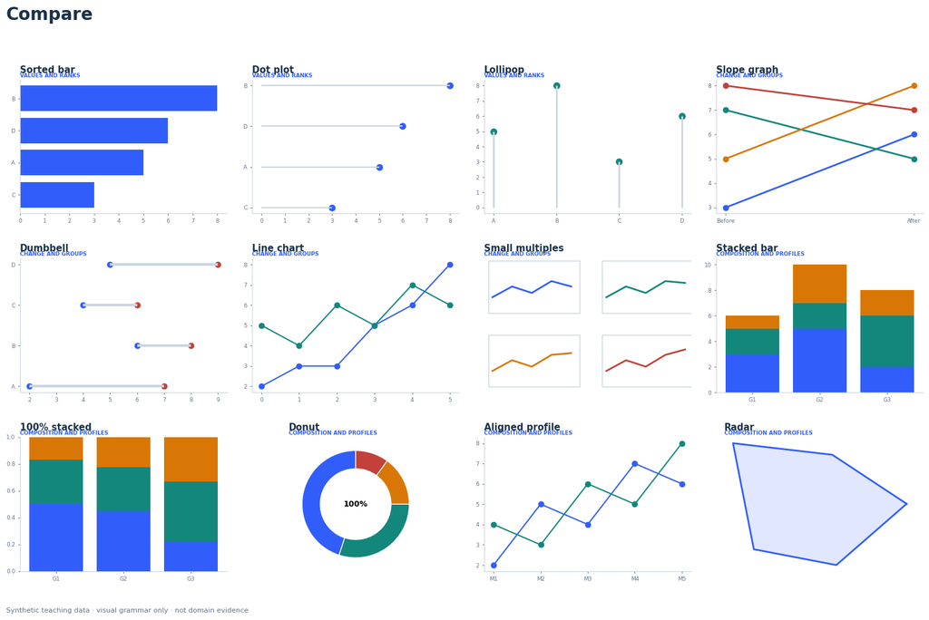

```python
# @title Render Compare gallery
compare_gallery = render_gallery("Compare", columns=4)
plt.show()
```

### 1.3 Understand Variation · 16 idioms

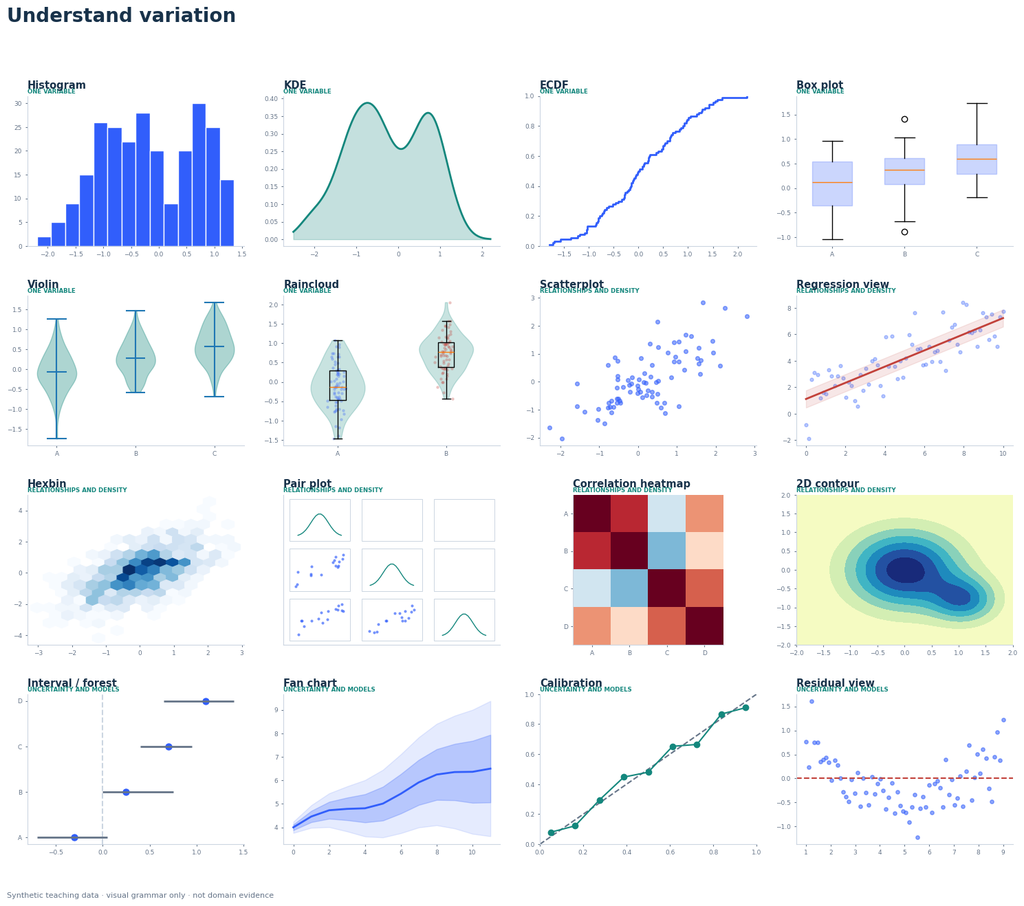

```python
# @title Render Understand Variation gallery
variation_gallery = render_gallery("Understand variation", columns=4)
plt.show()
```

### 1.4 Reveal Structure · 10 idioms

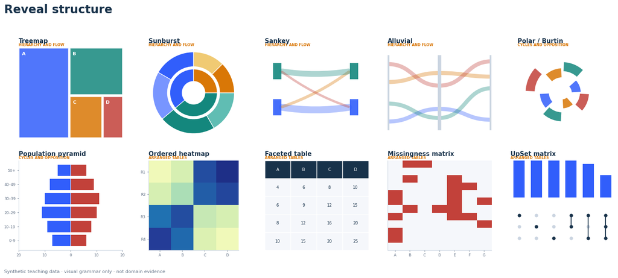

```python
# @title Render Reveal Structure gallery
structure_gallery = render_gallery("Reveal structure", columns=5)
plt.show()
```

# 2 · Run one idiom in Python or R

### Three things to inspect together

1. **Fit:** required dataset/attributes and action + target.
2. **Encoding:** marks and channels in the selected idiom.
3. **Algorithm:** transform → compute/layout → render → verify.

```python
# @title 2.1 · Store paired recipes (expand to inspect all source)
PYTHON_RECIPES = {'Sorted bar': "s = df.groupby('group')['value'].sum().sort_values()\ns.plot.barh(color='#315EFB')", 'Dot plot': "s = df.groupby('group')['value'].sum().sort_values()\nplt.hlines(s.index, 0, s); plt.scatter(s, s.index)", 'Lollipop': "s = df.groupby('group')['value'].sum().sort_values()\nplt.vlines(s.index, 0, s); plt.scatter(s.index, s)", 'Slope graph': "wide = df.pivot(index='group', columns='period', values='value')\nfor _, row in wide.iterrows(): plt.plot(wide.columns, row, marker='o')", 'Dumbbell': "wide = df.pivot(index='group', columns='condition', values='value')\nplt.hlines(wide.index, wide.iloc[:,0], wide.iloc[:,1]); plt.scatter(wide.iloc[:,0], wide.index); plt.scatter(wide.iloc[:,1], wide.index)", 'Line chart': "for key, g in df.sort_values('time').groupby('group'):\n    plt.plot(g.time, g.value, marker='o', label=key)", 'Small multiples': "import seaborn as sns\nsns.relplot(data=df, x='time', y='value', col='group', col_wrap=3, kind='line', facet_kws={'sharey':True})", 'Stacked bar': "wide = df.pivot_table(index='whole', columns='part', values='value', aggfunc='sum')\nwide.plot.bar(stacked=True)", '100% stacked': "wide = df.pivot_table(index='whole', columns='part', values='value', aggfunc='sum')\n(wide.div(wide.sum(axis=1), axis=0)).plot.bar(stacked=True)", 'Donut': "s = df.groupby('part')['value'].sum()\nplt.pie(s, labels=s.index, wedgeprops={'width':.38}, autopct='%1.0f%%')", 'Aligned profile': "for key, g in df.groupby('entity'):\n    plt.plot(g.metric, g.value, marker='o', label=key)", 'Radar': "theta = np.linspace(0, 2*np.pi, len(values), endpoint=False)\nax = plt.subplot(projection='polar'); ax.plot(np.r_[theta,theta[0]], np.r_[values,values[0]])", 'Histogram': "import seaborn as sns\nsns.histplot(data=df, x='value', bins=20)", 'KDE': "import seaborn as sns\nsns.kdeplot(data=df, x='value', bw_adjust=1, fill=True)", 'ECDF': "import seaborn as sns\nsns.ecdfplot(data=df, x='value')", 'Box plot': "import seaborn as sns\nsns.boxplot(data=df, x='group', y='value'); sns.stripplot(data=df, x='group', y='value', color='black', alpha=.35)", 'Violin': "import seaborn as sns\nsns.violinplot(data=df, x='group', y='value', inner='quartile')", 'Raincloud': "import PtitPrince as pt\npt.RainCloud(data=df, x='group', y='value', orient='v')", 'Scatterplot': "import altair as alt\nalt.Chart(df).mark_circle().encode(x='x:Q', y='y:Q', color='group:N', tooltip=list(df.columns))", 'Regression view': "import seaborn as sns\nsns.regplot(data=df, x='x', y='y', ci=95)", 'Hexbin': "plt.hexbin(df.x, df.y, gridsize=24, mincnt=1, cmap='viridis'); plt.colorbar(label='count')", 'Pair plot': "import seaborn as sns\nsns.pairplot(df, vars=['a','b','c'], hue='group', corner=True)", 'Correlation heatmap': "import seaborn as sns\ncorr = df.select_dtypes('number').corr()\nsns.heatmap(corr, vmin=-1, vmax=1, cmap='vlag', annot=True)", '2D contour': "grid = df.pivot(index='y', columns='x', values='z')\nplt.contourf(grid.columns, grid.index, grid.values, levels=10, cmap='viridis'); plt.colorbar()", 'Interval / forest': "plt.errorbar(df.estimate, df.label, xerr=[df.estimate-df.lower, df.upper-df.estimate], fmt='o')\nplt.axvline(0, color='0.5', lw=1)", 'Fan chart': 'plt.fill_between(df.time, df.q10, df.q90, alpha=.18)\nplt.fill_between(df.time, df.q25, df.q75, alpha=.32); plt.plot(df.time, df.median)', 'Calibration': 'from sklearn.calibration import CalibrationDisplay\nCalibrationDisplay.from_predictions(df.outcome, df.probability, n_bins=10)', 'Residual view': "import seaborn as sns\nsns.residplot(data=df, x='fitted', y='observed', lowess=True); plt.axhline(0, color='0.5')", 'Treemap': "import plotly.express as px\npx.treemap(df, path=['parent','child'], values='value', color='value')", 'Sunburst': "import plotly.express as px\npx.sunburst(df, path=['level1','level2'], values='value', color='level1')", 'Sankey': "import plotly.graph_objects as go\ngo.Figure(go.Sankey(node={'label':labels}, link={'source':source,'target':target,'value':value}))", 'Alluvial': "import plotly.express as px\npx.parallel_categories(df, dimensions=['stage1','stage2','stage3'], color='weight')", 'Polar / Burtin': 'from pycirclize import Circos\n# Map genuinely cyclic sectors and values; see the official pyCirclize examples.', 'Population pyramid': "y = np.arange(len(df))\nplt.barh(y, -df.left, label='Left'); plt.barh(y, df.right, label='Right'); plt.axvline(0, color='0.3')", 'Ordered heatmap': "import seaborn as sns\nordered = matrix.loc[row_order, col_order]\nsns.heatmap(ordered, cmap='viridis')", 'Faceted table': "styled = df.sort_values(['group','item']).style.format(precision=2).background_gradient(subset=['value'])\ndisplay(styled)", 'Missingness matrix': "import missingno as msno\nmsno.matrix(df.sort_values('group'))", 'UpSet matrix': "from upsetplot import UpSet, from_indicators\nUpSet(from_indicators(['A','B','C'], df), show_counts=True).plot()"}
R_RECIPES = {'Sorted bar': "library(ggplot2)\nggplot(df, aes(reorder(group, value), value)) + geom_col(fill='#315EFB') + coord_flip()", 'Dot plot': "library(ggplot2)\nggplot(df, aes(value, reorder(group, value))) + geom_point(size=3, colour='#315EFB')", 'Lollipop': 'library(ggplot2)\nggplot(df, aes(group, value)) + geom_segment(aes(xend=group, y=0, yend=value)) + geom_point(size=3)', 'Slope graph': 'library(ggplot2)\nggplot(df, aes(period, value, group=group, colour=group)) + geom_line() + geom_point()', 'Dumbbell': 'library(ggplot2)\nggplot(wide, aes(x=before, xend=after, y=group, yend=group)) + geom_segment() + geom_point(aes(x=before)) + geom_point(aes(x=after))', 'Line chart': 'library(ggplot2)\nggplot(df, aes(time, value, colour=group)) + geom_line() + geom_point()', 'Small multiples': 'library(ggplot2)\nggplot(df, aes(time, value)) + geom_line() + facet_wrap(~group) + coord_cartesian(ylim=range(df$value))', 'Stacked bar': 'library(ggplot2)\nggplot(df, aes(whole, value, fill=part)) + geom_col()', '100% stacked': "library(ggplot2)\nggplot(df, aes(whole, value, fill=part)) + geom_col(position='fill') + scale_y_continuous(labels=scales::percent)", 'Donut': "library(ggplot2)\nggplot(df, aes(x=2, y=value, fill=part)) + geom_col() + coord_polar(theta='y') + xlim(.5, 2.5)", 'Aligned profile': 'library(ggplot2)\nggplot(df, aes(metric, value, group=entity, colour=entity)) + geom_line() + geom_point()', 'Radar': 'library(ggplot2)\nggplot(df, aes(metric, value, group=entity, colour=entity)) + geom_polygon(fill=NA) + coord_polar()', 'Histogram': "library(ggplot2)\nggplot(df, aes(value)) + geom_histogram(bins=20, fill='#315EFB', colour='white')", 'KDE': "library(ggplot2)\nggplot(df, aes(value)) + geom_density(fill='#315EFB', alpha=.3, adjust=1)", 'ECDF': "library(ggplot2)\nggplot(df, aes(value)) + stat_ecdf(geom='step')", 'Box plot': 'library(ggplot2)\nggplot(df, aes(group, value)) + geom_boxplot() + geom_jitter(width=.08, alpha=.3)', 'Violin': 'library(ggplot2)\nggplot(df, aes(group, value)) + geom_violin() + geom_boxplot(width=.12)', 'Raincloud': 'library(ggplot2); library(ggdist)\nggplot(df, aes(group, value, fill=group)) + stat_halfeye() + geom_jitter(width=.08, alpha=.3)', 'Scatterplot': 'library(ggplot2)\nggplot(df, aes(x, y, colour=group)) + geom_point(alpha=.65)', 'Regression view': "library(ggplot2)\nggplot(df, aes(x, y)) + geom_point() + geom_smooth(method='lm', se=TRUE)", 'Hexbin': 'library(ggplot2); library(hexbin)\nggplot(df, aes(x, y)) + geom_hex(bins=24) + scale_fill_viridis_c()', 'Pair plot': "library(GGally)\nggpairs(df, columns=c('a','b','c'), aes(colour=group, alpha=.5))", 'Correlation heatmap': "library(ComplexHeatmap)\nHeatmap(cor(df[c('a','b','c')], use='pairwise.complete.obs'), name='r')", '2D contour': 'library(ggplot2)\nggplot(df, aes(x, y, z=z)) + geom_contour_filled() + coord_equal()', 'Interval / forest': 'library(forestplot)\nforestplot(labeltext=df$label, mean=df$estimate, lower=df$lower, upper=df$upper, zero=0)', 'Fan chart': 'library(ggplot2)\nggplot(df, aes(time, median)) + geom_ribbon(aes(ymin=q10,ymax=q90), alpha=.18) + geom_ribbon(aes(ymin=q25,ymax=q75), alpha=.32) + geom_line()', 'Calibration': 'library(ggplot2)\nggplot(calibration, aes(predicted, observed)) + geom_abline(slope=1, intercept=0, linetype=2) + geom_line() + geom_point()', 'Residual view': "library(ggplot2)\nggplot(df, aes(fitted, residual)) + geom_hline(yintercept=0, colour='grey60') + geom_point() + geom_smooth(se=FALSE)", 'Treemap': 'library(ggplot2); library(treemapify)\nggplot(df, aes(area=value, fill=parent, label=child)) + geom_treemap() + geom_treemap_text()', 'Sunburst': "library(plotly)\nplot_ly(df, labels=~label, parents=~parent, values=~value, type='sunburst', branchvalues='total')", 'Sankey': "library(networkD3)\nsankeyNetwork(Links=links, Nodes=nodes, Source='source', Target='target', Value='value', NodeID='name')", 'Alluvial': 'library(ggplot2); library(ggalluvial)\nggplot(df, aes(axis1=stage1, axis2=stage2, axis3=stage3, y=weight)) + geom_alluvium(aes(fill=stage1)) + geom_stratum()', 'Polar / Burtin': 'library(circlize)\n# Map genuinely cyclic sectors and quantitative values; see the official circlize book.', 'Population pyramid': "library(ggplot2)\nlong$plot_value <- ifelse(long$side=='Left', -long$value, long$value)\nggplot(long, aes(plot_value, ordered_group, fill=side)) + geom_col() + geom_vline(xintercept=0)", 'Ordered heatmap': "library(ComplexHeatmap)\nHeatmap(matrix[row_order, col_order], name='value', cluster_rows=FALSE, cluster_columns=FALSE)", 'Faceted table': "library(reactable)\nreactable(df, groupBy='group', searchable=TRUE, defaultSorted='item')", 'Missingness matrix': "library(ComplexHeatmap)\nHeatmap(is.na(df) * 1, name='missing', col=c('0'='white','1'='#C2413A'))", 'UpSet matrix': "library(ComplexHeatmap)\nm = make_comb_mat(df[c('A','B','C')]); UpSet(m)"}
assert set(PYTHON_RECIPES) == set(idiom_names)
assert set(R_RECIPES) == set(idiom_names)
print("Paired recipes ready:", len(PYTHON_RECIPES), "Python +", len(R_RECIPES), "R")
```

```
Paired recipes ready: 38 Python + 38 R
```

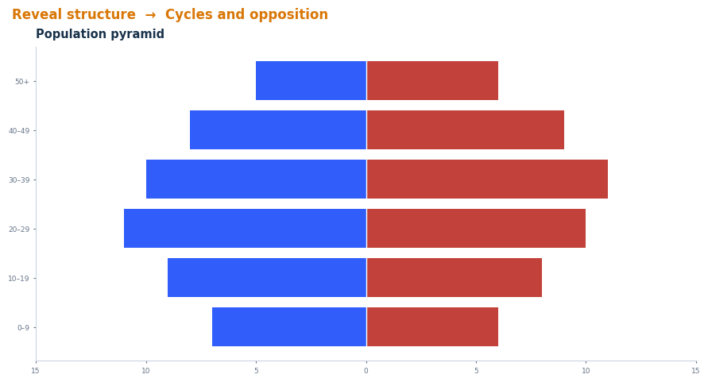

| Decision | Selected answer |
| --- | --- |
| Use when | Compare two opposing populations across the same ordered categories. |
| Required data | Table · ordered groups + two opposing categories + values |
| Action + target | Compare → opposition across shared groups |
| Marks + channels | opposing bars · signed length + shared order |
| Algorithm | align ordered groups → sign one category negative → mirror shared zero → label absolute values |
| Caution | Validate scale, labels, accessibility, and evidence boundary. |

```python
# @title 2.2 · Select a leaf and render its worked example
IDIOM = "Population pyramid" # @param ["Sorted bar", "Dot plot", "Lollipop", "Slope graph", "Dumbbell", "Line chart", "Small multiples", "Stacked bar", "100% stacked", "Donut", "Aligned profile", "Radar", "Histogram", "KDE", "ECDF", "Box plot", "Violin", "Raincloud", "Scatterplot", "Regression view", "Hexbin", "Pair plot", "Correlation heatmap", "2D contour", "Interval / forest", "Fan chart", "Calibration", "Residual view", "Treemap", "Sunburst", "Sankey", "Alluvial", "Polar / Burtin", "Population pyramid", "Ordered heatmap", "Faceted table", "Missingness matrix", "UpSet matrix"]

selected = idiom_catalog.loc[idiom_catalog.idiom.eq(IDIOM)].iloc[0]
fig, ax = plt.subplots(figsize=(8.8, 4.7), constrained_layout=True)
draw_idiom(ax, IDIOM)
fig.suptitle(f"{selected.root}  →  {selected.family}", x=.01, ha="left", fontsize=12, color=ROOT_COLORS[selected.root], fontweight="bold")
plt.show()

detail = pd.DataFrame({
    "Decision": ["Use when", "Required data", "Action + target", "Marks + channels", "Algorithm", "Caution"],
    "Selected answer": [selected.selection_cue, selected.data_requirement, selected.action_target, selected.marks_channels, selected.algorithm, selected.caution or "Validate scale, labels, accessibility, and evidence boundary."],
})
display(detail.style.hide(axis="index"))
```

````python
# @title 2.3 · Show the paired Python and R implementation
selected = idiom_catalog.loc[idiom_catalog.idiom.eq(IDIOM)].iloc[0]
display(Markdown(f"""
### {IDIOM}: paired implementation

| Python | R |
|---|---|
| [{selected.python_tool}]({selected.python_url}) | [{selected.r_tool}]({selected.r_url}) |

**Python recipe**

```python
{PYTHON_RECIPES[IDIOM]}
```

**R recipe**

```r
{R_RECIPES[IDIOM]}
```

These snippets state the production grammar; replace placeholder column names with your verified schema. The rendered teaching example above uses the notebook's dependency-light Matplotlib renderer so all 38 leaves work in one runtime.
"""))
````

Population pyramid: paired implementation

| Python | R |
| --- | --- |
| [Matplotlib](https://matplotlib.org/stable/gallery/index.html) | [ggplot2](https://ggplot2.tidyverse.org/) |

**Python recipe**

```
y = np.arange(len(df))
plt.barh(y, -df.left, label='Left'); plt.barh(y, df.right, label='Right'); plt.axvline(0, color='0.3')
```

**R recipe**

```
library(ggplot2)
long$plot_value <- ifelse(long$side=='Left', -long$value, long$value)
ggplot(long, aes(plot_value, ordered_group, fill=side)) + geom_col() + geom_vline(xintercept=0)
```

These snippets state the production grammar; replace placeholder column names with your verified schema. The rendered teaching example above uses the notebook's dependency-light Matplotlib renderer so all 38 leaves work in one runtime.

```python
# @title 2.4 · Optional: execute the selected R recipe
RUN_SELECTED_R = False # @param {type:"boolean"}

if not RUN_SELECTED_R:
    print("R execution is off. The complete R recipe is visible above and will be exported below.")
else:
    print("This optional path requires an R runtime plus the selected package.")
    print("Recommended classroom workflow: copy the displayed recipe into an R Colab/runtime,")
    print("or run the exported idiom_recipes.R file in RStudio. Install only the package named above.")
    print("Selected package:", selected.r_tool, "·", selected.r_url)
```

```
R execution is off. The complete R recipe is visible above and will be exported below.
```